# Analyses for Susa (2016) mark-recapture study

Johanna Kiss et al.

2023-12-07

### Describing movement of different sized males and females in Lethrus beetles on field by using one model.

Using 1 model for each response variable (e.g., number of recaptures, travelled distances…) instead of 2.

To do that we reanalyse data and test the effect of the created 4-level factor ( female, small male, middle male, large male)

```r
all.dist<-read.csv(file="rel.full.data.csv",header=TRUE,nrow=FALSE)
all.capt<-read.csv(file="rel.aa.df.data.csv",header=TRUE,nrow=FALSE)
```

```r
head(all.dist)
```

```
##   id no.cap sex     age     aktiv       date cap.recap comment  x.coord
## 1  3      2   f juvenil           2016-03-30         r    died 738887.6
## 2 35      2   f juvenil       dig 2016-03-21         r         738822.9
## 3 37      3   f juvenil travelled 2016-03-30         r         738782.8
## 4 37      4   f juvenil travelled 2016-04-07         r         738782.4
## 5 46      2   f juvenil     dicon 2016-05-02         r         738906.5
## 6 48      3   f juvenil      nest 2016-03-31         r         738813.3
##    y.coord elev.map.b Distance  body proc date.of.catch id.1 diff.days
## 1 326513.5   221.0469 1.692479 12.09    0    2016-03-17    3        13
## 2 326585.9   243.7310 2.023965 12.20    0    2016-03-18   35         3
## 3 326601.2   248.3841 9.403658 10.69    0    2016-03-18   37        12
## 4 326607.9   248.0072 6.789462 10.69    0    2016-03-18   37         8
## 5 326539.9   225.3828 5.441226 10.67    0    2016-03-21   46        42
## 6 326583.9   239.7425 2.813426 11.71    0    2016-03-21   48         9
##   rel.bodywidth    st.date day day.from.1st.catch
## 1    0.50708209 2016-03-17  13                  0
## 2    0.66352686 2016-03-17   4                  1
## 3   -1.48403316 2016-03-17  13                  1
## 4   -1.48403316 2016-03-17  21                  1
## 5   -1.51247766 2016-03-17  46                  4
## 6   -0.03336348 2016-03-17  14                  4
```

```r
head(all.capt)
```

```
##   ID sex B.width Tusk days     Age no.recaptures  tot.dist  max.dist dist.a.day
## 1  3   f   12.09    0   13 juvenil             1  1.692479  1.692479  0.1301907
## 2 35   f   12.20    0    3 juvenil             1  2.023965  2.023965  0.6746550
## 3 37   f   10.69    0   20 juvenil             2 16.193120  9.403658  0.8096560
## 4 46   f   10.67    0   42 juvenil             1  5.441226  5.441226  0.1295530
## 5 48   f   11.71    0   10 juvenil             2  5.086223  2.813426  0.5086223
## 6 55   f   11.97    0   23     old             6 34.572775 21.058028  1.5031642
##   rel.bodywidth
## 1    0.49249005
## 2    0.64981503
## 3   -1.50982789
## 4   -1.53843243
## 5   -0.05099625
## 6    0.32086280
```

Previously, based on a segmented regression on body size we determined the breakpoints, now we use them to create male categories:

```r
library(dplyr)
new.all.capt<-all.capt%>%
  mutate(sex.cat= case_when(sex=="m" & B.width <= 11.10 ~ 'small.male',
                            sex=="m" & B.width > 12.37 ~ 'large.male',
                            sex=="m" & B.width > 11.10 & B.width <= 12.37 ~ 'middle.male',
                            sex=="f" ~ 'female'))
```

```r
library(dplyr)
new.all.dist<-all.dist%>%
  mutate(sex.cat= case_when(sex=="m" & body <= 11.10 ~ 'small.male',
                            sex=="m" & body > 12.37 ~ 'large.male',
                            sex=="m" & body > 11.10 & body <= 12.37 ~ 'middle.male',
                            sex=="f" ~ 'female'))
```

Load some packages:

```r
library(plotrix)
library(emmeans)
library(plyr)
library(dplyr)
library(ggplot2)
library(scales)
library(MASS)
library(lme4)
library(pbkrtest)
library(pscl)
library(lattice)
library(partR2)
library(rsq)
library(segmented)
library(interactions)
library(jtools)
library(bbmle)
library(cowplot)
```

#### New analyses on the number of recaptures

```r
str(new.all.capt)
```

```
## 'data.frame':    1624 obs. of  12 variables:
##  $ ID           : int  3 35 37 46 48 55 57 68 72 92 ...
##  $ sex          : chr  "f" "f" "f" "f" ...
##  $ B.width      : num  12.1 12.2 10.7 10.7 11.7 ...
##  $ Tusk         : num  0 0 0 0 0 0 0 0 0 0 ...
##  $ days         : int  13 3 20 42 10 23 22 26 8 43 ...
##  $ Age          : chr  "juvenil" "juvenil" "juvenil" "juvenil" ...
##  $ no.recaptures: int  1 1 2 1 2 6 11 2 2 1 ...
##  $ tot.dist     : num  1.69 2.02 16.19 5.44 5.09 ...
##  $ max.dist     : num  1.69 2.02 9.4 5.44 2.81 ...
##  $ dist.a.day   : num  0.13 0.675 0.81 0.13 0.509 ...
##  $ rel.bodywidth: num  0.492 0.65 -1.51 -1.538 -0.051 ...
##  $ sex.cat      : chr  "female" "female" "female" "female" ...
```

```r
new.all.capt.m<-new.all.capt[new.all.capt$sex=="m",]

new.all.capt.m<-new.all.capt.m[new.all.capt.m$Tusk>0,]

str(new.all.capt.m)
```

```
## 'data.frame':    835 obs. of  12 variables:
##  $ ID           : int  6 14 17 36 38 49 50 52 56 65 ...
##  $ sex          : chr  "m" "m" "m" "m" ...
##  $ B.width      : num  13.7 13.6 13 13.1 11.6 ...
##  $ Tusk         : num  4.58 4.11 4.13 4.06 3.4 3.72 1.81 2.36 3.81 3.8 ...
##  $ days         : int  21 7 4 16 16 1 4 31 4 10 ...
##  $ Age          : chr  "juvenil" "juvenil" "juvenil" "juvenil" ...
##  $ no.recaptures: int  2 1 1 1 1 2 3 7 2 1 ...
##  $ tot.dist     : num  116.13 2.83 6.11 5.14 6.53 ...
##  $ max.dist     : num  112.84 2.83 6.11 5.14 6.53 ...
##  $ dist.a.day   : num  5.53 0.404 1.526 0.322 0.408 ...
##  $ rel.bodywidth: num  1.671 1.559 0.867 0.923 -0.662 ...
##  $ sex.cat      : chr  "large.male" "large.male" "large.male" "large.male" ...
```

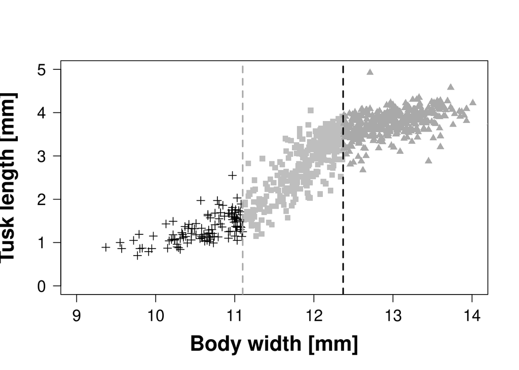

```r
custom_pch <- c(3,15,17)

plot(new.all.capt.m$Tusk~new.all.capt.m$B.width, type="n", xlab="Body width [mm]", ylab="Tusk length [mm]",las=1,  cex.axis=1.3, cex=1, cex.lab=1.7, las=1, font.lab=2.3, font.main=4.3, ylim=c(0, 5),xlim=c(9,14))
points(new.all.capt.m$Tusk~new.all.capt.m$B.width, subset=new.all.capt.m$sex.cat=="small.male", pch=3,
       col=1)
points(new.all.capt.m$Tusk~new.all.capt.m$B.width, subset=new.all.capt.m$sex.cat=="middle.male", pch=15,
       col="grey")

points(new.all.capt.m$Tusk~new.all.capt.m$B.width, subset=new.all.capt.m$sex.cat=="large.male", pch=17,
       col="darkgrey")

abline(v=c(11.10, 12.37), col=c("darkgrey", "black"), lty=2, lwd=2)
```

Lets see the models:

```r
new.p.rec<-glm(no.recaptures~sex.cat,new.all.capt,family=poisson)
drop1(new.p.rec,test="Chisq")
```

```
## Single term deletions
##
## Model:
## no.recaptures ~ sex.cat
##         Df Deviance    AIC    LRT  Pr(>Chi)
## <none>       2277.9 3170.2
## sex.cat  3   2310.6 3196.9 32.761 3.616e-07 ***
## ---
## Signif. codes:  0 '***' 0.001 '**' 0.01 '*' 0.05 '.' 0.1 ' ' 1
```

```r
new.qp.rec<-glm(no.recaptures~sex.cat,new.all.capt,family=quasipoisson)
drop1(new.qp.rec,test="Chisq")
```

```
## Single term deletions
##
## Model:
## no.recaptures ~ sex.cat
##         Df Deviance scaled dev. Pr(>Chi)
## <none>       2277.9
## sex.cat  3   2310.6       12.46 0.005962 **
## ---
## Signif. codes:  0 '***' 0.001 '**' 0.01 '*' 0.05 '.' 0.1 ' ' 1
```

```r
new.zp.rec<-zeroinfl(no.recaptures~sex.cat,new.all.capt,dist='poisson')
drop1(new.zp.rec,test="Chisq")
```

```
## Single term deletions
##
## Model:
## no.recaptures ~ sex.cat
##         Df    AIC    LRT  Pr(>Chi)
## <none>     2797.6
## sex.cat  6 2816.2 30.619 2.997e-05 ***
## ---
## Signif. codes:  0 '***' 0.001 '**' 0.01 '*' 0.05 '.' 0.1 ' ' 1
```

```r
new.znb.rec<-zeroinfl(no.recaptures~sex.cat,new.all.capt,dist='negbin')
drop1(new.znb.rec,test="Chisq")
```

```
## Single term deletions
##
## Model:
## no.recaptures ~ sex.cat
##         Df    AIC    LRT Pr(>Chi)
## <none>     2675.8
## sex.cat  6 2677.7 13.897  0.03081 *
## ---
## Signif. codes:  0 '***' 0.001 '**' 0.01 '*' 0.05 '.' 0.1 ' ' 1
```

```r
new.hnb.rec<-hurdle(no.recaptures~sex.cat,new.all.capt,dist='negbin')
drop1(new.hnb.rec,test="Chisq")
```

```
## Single term deletions
##
## Model:
## no.recaptures ~ sex.cat
##         Df    AIC    LRT Pr(>Chi)
## <none>     2662.4
## sex.cat  6 2668.5 18.104 0.005977 **
## ---
## Signif. codes:  0 '***' 0.001 '**' 0.01 '*' 0.05 '.' 0.1 ' ' 1
```

```r
new.nb.rec<-glm.nb(no.recaptures~sex.cat,new.all.capt)
drop1(new.nb.rec,test="Chisq")
```

```
## Single term deletions
##
## Model:
## no.recaptures ~ sex.cat
##         Df Deviance    AIC    LRT Pr(>Chi)
## <none>       978.33 2665.8
## sex.cat  3   992.39 2673.9 14.054 0.002833 **
## ---
## Signif. codes:  0 '***' 0.001 '**' 0.01 '*' 0.05 '.' 0.1 ' ' 1
```

Lets compare the models

```r
logLik(new.p.rec)
```

```
## 'log Lik.' -1581.086 (df=4)
```

```r
logLik(new.nb.rec)
```

```
## 'log Lik.' -1328.911 (df=5)
```

```r
logLik(new.hnb.rec)
```

```
## 'log Lik.' -1322.188 (df=9)
```

```r
logLik(new.znb.rec)
```

```
## 'log Lik.' -1328.911 (df=9)
```

```r
logLik(new.zp.rec)
```

```
## 'log Lik.' -1390.776 (df=8)
```

```r
logLik(new.qp.rec)
```

```
## 'log Lik.' NA (df=5)
```

```r
AIC(new.p.rec)
```

```
## [1] 3170.173
```

```r
AIC(new.nb.rec)
```

```
## [1] 2667.823
```

```r
AIC(new.hnb.rec)
```

```
## [1] 2662.377
```

```r
AIC(new.znb.rec)
```

```
## [1] 2675.823
```

```r
AIC(new.zp.rec)
```

```
## [1] 2797.552
```

```r
AIC(new.qp.rec)
```

```
## [1] NA
```

HNB and NB models seemed to be the best.

```r
drop1(new.hnb.rec,test="Chisq")
```

```
## Single term deletions
##
## Model:
## no.recaptures ~ sex.cat
##         Df    AIC    LRT Pr(>Chi)
## <none>     2662.4
## sex.cat  6 2668.5 18.104 0.005977 **
## ---
## Signif. codes:  0 '***' 0.001 '**' 0.01 '*' 0.05 '.' 0.1 ' ' 1
```

```r
drop1(new.nb.rec,test="Chisq")
```

```
## Single term deletions
##
## Model:
## no.recaptures ~ sex.cat
##         Df Deviance    AIC    LRT Pr(>Chi)
## <none>       978.33 2665.8
## sex.cat  3   992.39 2673.9 14.054 0.002833 **
## ---
## Signif. codes:  0 '***' 0.001 '**' 0.01 '*' 0.05 '.' 0.1 ' ' 1
```

```r
ph.test.rec<-emmeans(new.nb.rec, ~sex.cat,type="response")
test(ph.test.rec)
```

```
##  sex.cat     response     SE  df null z.ratio p.value
##  female         0.330 0.0293 Inf    1 -12.483  <.0001
##  large.male     0.534 0.0604 Inf    1  -5.541  <.0001
##  middle.male    0.497 0.0624 Inf    1  -5.571  <.0001
##  small.male     0.369 0.0851 Inf    1  -4.322  <.0001
##
## Tests are performed on the log scale
```

```r
pairs(ph.test.rec)
```

```
##  contrast                 ratio     SE  df null z.ratio p.value
##  female / large.male      0.618 0.0889 Inf    1  -3.349  0.0045
##  female / middle.male     0.664 0.1021 Inf    1  -2.664  0.0387
##  female / small.male      0.893 0.2206 Inf    1  -0.457  0.9683
##  large.male / middle.male 1.075 0.1816 Inf    1   0.427  0.9738
##  large.male / small.male  1.446 0.3713 Inf    1   1.437  0.4761
##  middle.male / small.male 1.345 0.3530 Inf    1   1.131  0.6704
##
## P value adjustment: tukey method for comparing a family of 4 estimates
## Tests are performed on the log scale
```

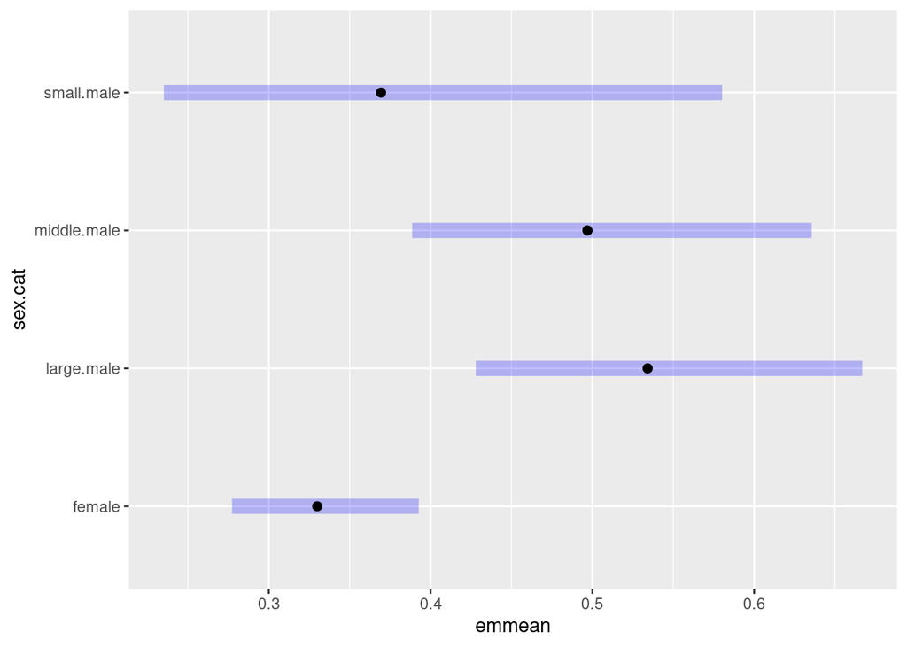

```r
plot(ph.test.rec)
```

```r
ph.test.rec2<-emmeans(new.nb.rec, ~sex.cat,type="link")
test(ph.test.rec2)
```

```
##  sex.cat     emmean     SE  df z.ratio p.value
##  female      -1.109 0.0888 Inf -12.483  <.0001
##  large.male  -0.627 0.1132 Inf  -5.541  <.0001
##  middle.male -0.699 0.1255 Inf  -5.571  <.0001
##  small.male  -0.996 0.2304 Inf  -4.322  <.0001
##
## Results are given on the log (not the response) scale.
```

```r
pairs(ph.test.rec2)
```

```
##  contrast                 estimate    SE  df z.ratio p.value
##  female - large.male       -0.4818 0.144 Inf  -3.349  0.0045
##  female - middle.male      -0.4096 0.154 Inf  -2.664  0.0387
##  female - small.male       -0.1129 0.247 Inf  -0.457  0.9683
##  large.male - middle.male   0.0722 0.169 Inf   0.427  0.9738
##  large.male - small.male    0.3689 0.257 Inf   1.437  0.4761
##  middle.male - small.male   0.2967 0.262 Inf   1.131  0.6704
##
## Results are given on the log (not the response) scale.
## P value adjustment: tukey method for comparing a family of 4 estimates
```

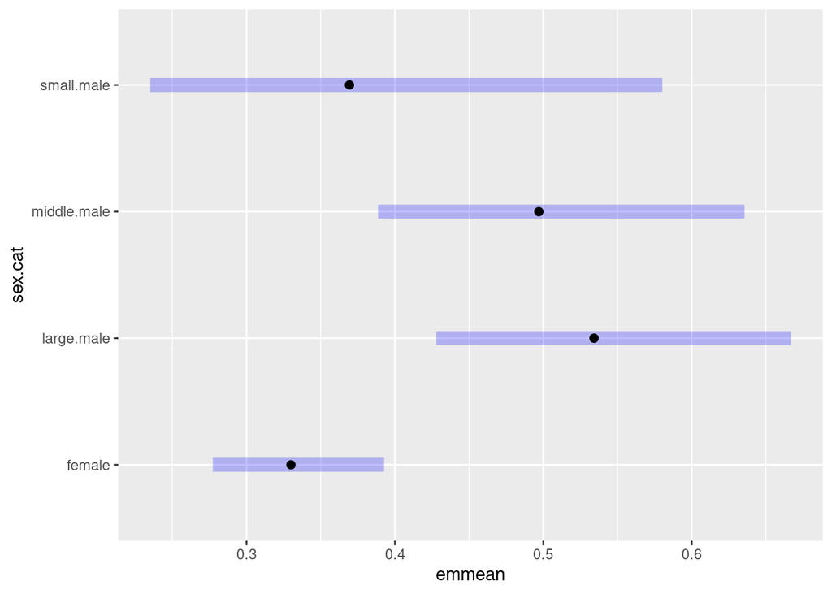

```r
plot(ph.test.rec)
```

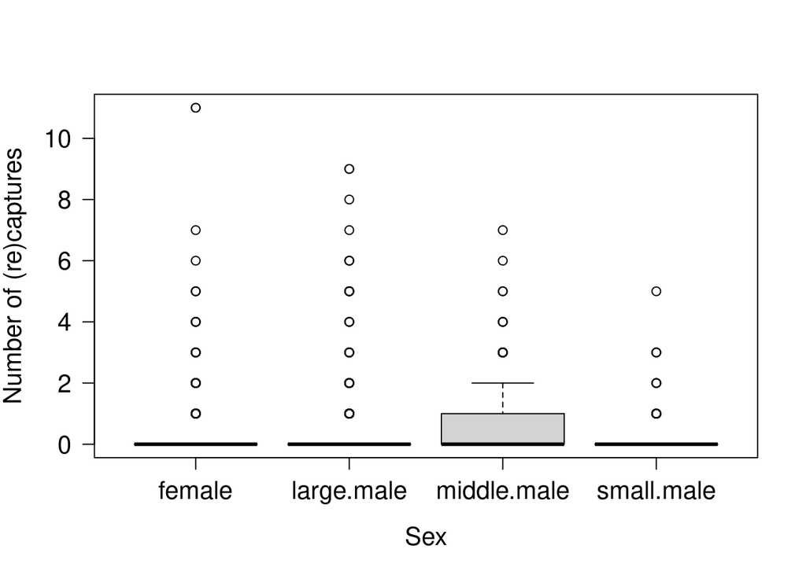

```r
boxplot(new.all.capt$no.recaptures~new.all.capt$sex.cat,xlab="Sex",ylab="Number of (re)captures",las=1, lwd=1,font.lab=2, cex.lab=1.3,cex.axis=1.3,font.main=2)
```

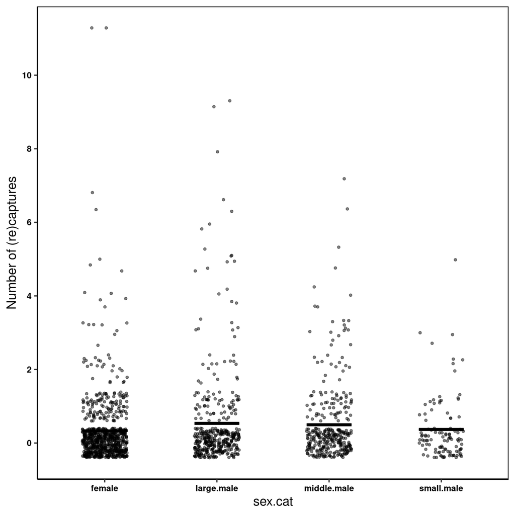

```r
new1<-ggplot(new.all.capt,aes(sex.cat,no.recaptures),line.thickness=1.2) +theme_classic(base_size = 18) + geom_jitter(width=0.2,alpha=0.5)+scale_y_continuous(name="Number of (re)captures",breaks= pretty_breaks()) +theme (axis.text.x = element_text(face = "bold", size=12,colour="black"), axis.text.y = element_text(face = "bold", size = 12,colour="black"),panel.border= element_rect(color = "black",fill=NA,size=1), legend.text=element_text(size=14),legend.title=element_text(size=16))
new.plot1<-new.all.capt[,c(7,12)]
new.plot1.sum<-aggregate(.~sex.cat,mean,data=new.plot1)



new1+ theme(plot.title.position = "plot")+geom_crossbar(data=new.plot1.sum, aes(ymin=no.recaptures,ymax=no.recaptures),size=0.8,width=0.4)
```

Lets see now the effect size:

```r
rsq.partial(new.nb.rec,type='kl')
```

```
## $adjustment
## [1] FALSE
##
## $variable
## [1] "sex.cat"
##
## $partial.rsq
## [1] 0.01416148
```

Females and male morphs showed a small effect size: 0.014.

#### New analyses on the number of days

Lets see the models:

```r
new.p.days<-glm(days~(sex.cat*no.recaptures)^2,new.all.capt,family=poisson,subset=new.all.capt$no.recaptures>0)
drop1(new.p.days,test="Chisq")
```

```
## Single term deletions
##
## Model:
## days ~ (sex.cat * no.recaptures)^2
##                       Df Deviance    AIC    LRT Pr(>Chi)
## <none>                     2449.2 3846.6
## sex.cat:no.recaptures  3   2461.8 3853.1 12.587  0.00562 **
## ---
## Signif. codes:  0 '***' 0.001 '**' 0.01 '*' 0.05 '.' 0.1 ' ' 1
```

```r
new.p.days1<-update(new.p.days,.~.-sex.cat:no.recaptures)
drop1(new.p.days1,test="Chisq")
```

```
## Single term deletions
##
## Model:
## days ~ sex.cat + no.recaptures
##               Df Deviance    AIC     LRT  Pr(>Chi)
## <none>             2461.8 3853.1
## sex.cat        3   2498.9 3884.3  37.144  4.29e-08 ***
## no.recaptures  1   2676.2 4065.6 214.418 < 2.2e-16 ***
## ---
## Signif. codes:  0 '***' 0.001 '**' 0.01 '*' 0.05 '.' 0.1 ' ' 1
```

```r
new.qp.days<-glm(days~(sex.cat*no.recaptures)^2,new.all.capt,family=quasipoisson,subset=new.all.capt$no.recaptures>0)
drop1(new.qp.days,test="Chisq")
```

```
## Single term deletions
##
## Model:
## days ~ (sex.cat * no.recaptures)^2
##                       Df Deviance scaled dev. Pr(>Chi)
## <none>                     2449.2
## sex.cat:no.recaptures  3   2461.8      1.7667   0.6222
```

```r
new.qp.days1<-update(new.qp.days,.~.-sex.cat:no.recaptures)
drop1(new.qp.days1,test="Chisq")
```

```
## Single term deletions
##
## Model:
## days ~ sex.cat + no.recaptures
##               Df Deviance scaled dev. Pr(>Chi)
## <none>             2461.8
## sex.cat        3   2498.9      5.2089   0.1571
## no.recaptures  1   2676.2     30.0688 4.17e-08 ***
## ---
## Signif. codes:  0 '***' 0.001 '**' 0.01 '*' 0.05 '.' 0.1 ' ' 1
```

```r
new.zp.days<-zeroinfl(days~(sex.cat*no.recaptures)^2,new.all.capt,dist='poisson',subset=new.all.capt$no.recaptures>0)
drop1(new.zp.days,test="Chisq")
```

```
## Single term deletions
##
## Model:
## days ~ (sex.cat * no.recaptures)^2
##                       Df    AIC    LRT Pr(>Chi)
## <none>                   3677.7
## sex.cat:no.recaptures  6 3676.0 10.335   0.1112
```

```r
new.zp.days1<-update(new.zp.days,.~.-sex.cat:no.recaptures)
drop1(new.zp.days1,test="Chisq")
```

```
## Single term deletions
##
## Model:
## days ~ sex.cat + no.recaptures
##               Df    AIC     LRT  Pr(>Chi)
## <none>           3676.0
## sex.cat        6 3694.5  30.426 3.262e-05 ***
## no.recaptures  2 3862.3 190.246 < 2.2e-16 ***
## ---
## Signif. codes:  0 '***' 0.001 '**' 0.01 '*' 0.05 '.' 0.1 ' ' 1
```

```r
new.znb.days<-zeroinfl(days~(sex.cat*no.recaptures)^2,new.all.capt,dist='negbin',subset=new.all.capt$no.recaptures>0)
drop1(new.znb.days,test="Chisq")
```

```
## Single term deletions
##
## Model:
## days ~ (sex.cat * no.recaptures)^2
##                       Df    AIC    LRT Pr(>Chi)
## <none>                   2512.4
## sex.cat:no.recaptures  6 2501.7 1.2907   0.9722
```

```r
new.znb.days1<-update(new.znb.days,.~.-sex.cat:no.recaptures)
drop1(new.znb.days1,test="Chisq")
```

```
## Single term deletions
##
## Model:
## days ~ sex.cat + no.recaptures
##               Df    AIC     LRT  Pr(>Chi)
## <none>           2501.7
## sex.cat        6 2496.9  7.1698    0.3054
## no.recaptures  2 2527.4 29.6778 3.594e-07 ***
## ---
## Signif. codes:  0 '***' 0.001 '**' 0.01 '*' 0.05 '.' 0.1 ' ' 1
```

```r
new.hnb.days<-hurdle(days~(sex.cat*no.recaptures)^2,new.all.capt,dist='negbin',subset=new.all.capt$no.recaptures>0)
drop1(new.hnb.days,test="Chisq")
```

```
## Single term deletions
##
## Model:
## days ~ (sex.cat * no.recaptures)^2
##                       Df    AIC    LRT Pr(>Chi)
## <none>                   2502.9
## sex.cat:no.recaptures  6 2492.1 1.2067   0.9766
```

```r
new.hnb.days1<-update(new.hnb.days,.~.-sex.cat:no.recaptures)
drop1(new.hnb.days1,test="Chisq")
```

```
## Single term deletions
##
## Model:
## days ~ sex.cat + no.recaptures
##               Df    AIC    LRT  Pr(>Chi)
## <none>           2492.1
## sex.cat        6 2487.2  7.061    0.3153
## no.recaptures  2 2525.9 37.841 6.065e-09 ***
## ---
## Signif. codes:  0 '***' 0.001 '**' 0.01 '*' 0.05 '.' 0.1 ' ' 1
```

```r
new.nb.days<-glm.nb(days~(sex.cat*no.recaptures)^2,new.all.capt,subset=new.all.capt$no.recaptures>0)
drop1(new.nb.days,test="Chisq")
```

```
## Single term deletions
##
## Model:
## days ~ (sex.cat * no.recaptures)^2
##                       Df Deviance    AIC    LRT Pr(>Chi)
## <none>                     424.88 2497.7
## sex.cat:no.recaptures  3   426.21 2493.0 1.3284   0.7224
```

```r
new.nb.days1<-update(new.nb.days,.~.-sex.cat:no.recaptures)
drop1(new.nb.days1,test="Chisq")
```

```
## Single term deletions
##
## Model:
## days ~ sex.cat + no.recaptures
##               Df Deviance    AIC     LRT  Pr(>Chi)
## <none>             424.85 2493.0
## sex.cat        3   430.40 2492.5  5.5476    0.1358
## no.recaptures  1   452.38 2518.5 27.5211 1.554e-07 ***
## ---
## Signif. codes:  0 '***' 0.001 '**' 0.01 '*' 0.05 '.' 0.1 ' ' 1
```

Lets compare the models

```r
logLik(new.p.days1)
```

```
## 'log Lik.' -1921.573 (df=5)
```

```r
logLik(new.nb.days1)
```

```
## 'log Lik.' -1241.495 (df=6)
```

```r
logLik(new.hnb.days1)
```

```
## 'log Lik.' -1235.042 (df=11)
```

```r
logLik(new.znb.days1)
```

```
## 'log Lik.' -1239.859 (df=11)
```

```r
logLik(new.zp.days1)
```

```
## 'log Lik.' -1828.02 (df=10)
```

```r
logLik(new.qp.days1)
```

```
## 'log Lik.' NA (df=6)
```

```r
AIC(new.p.days1)
```

```
## [1] 3853.145
```

```r
AIC(new.nb.days1)
```

```
## [1] 2494.99
```

```r
AIC(new.hnb.days1)
```

```
## [1] 2492.085
```

```r
AIC(new.znb.days1)
```

```
## [1] 2501.717
```

```r
AIC(new.zp.days1)
```

```
## [1] 3676.04
```

```r
AIC(new.qp.days1)
```

```
## [1] NA
```

Here also HNB and NB models seemed to be the best.

```r
drop1(new.hnb.days1,test="Chisq")
```

```
## Single term deletions
##
## Model:
## days ~ sex.cat + no.recaptures
##               Df    AIC    LRT  Pr(>Chi)
## <none>           2492.1
## sex.cat        6 2487.2  7.061    0.3153
## no.recaptures  2 2525.9 37.841 6.065e-09 ***
## ---
## Signif. codes:  0 '***' 0.001 '**' 0.01 '*' 0.05 '.' 0.1 ' ' 1
```

```r
drop1(new.nb.days1,test="Chisq")
```

```
## Single term deletions
##
## Model:
## days ~ sex.cat + no.recaptures
##               Df Deviance    AIC     LRT  Pr(>Chi)
## <none>             424.85 2493.0
## sex.cat        3   430.40 2492.5  5.5476    0.1358
## no.recaptures  1   452.38 2518.5 27.5211 1.554e-07 ***
## ---
## Signif. codes:  0 '***' 0.001 '**' 0.01 '*' 0.05 '.' 0.1 ' ' 1
```

Its seems that sex and male morphs had no significant effect on the number of days individuals were seen on field.

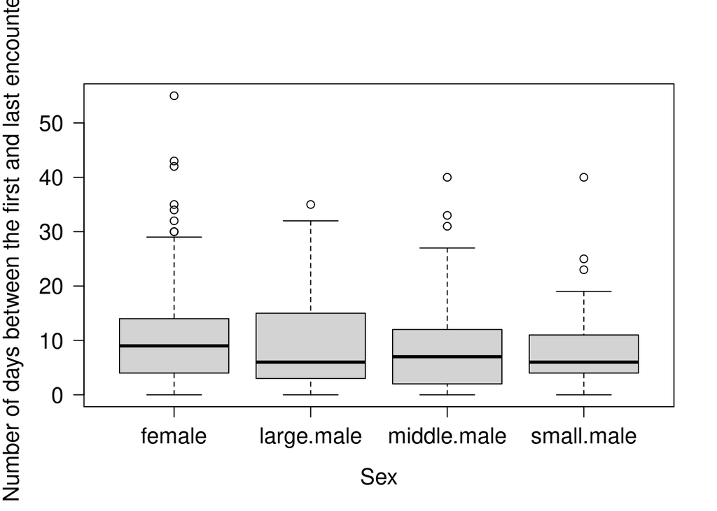

```r
new.all.capt2<-new.all.capt[new.all.capt$no.recaptures>0,]


boxplot(new.all.capt2$days~new.all.capt2$sex.cat,xlab="Sex",ylab="Number of days between the first and last encounter",las=1, lwd=1,font.lab=2, cex.lab=1.3,cex.axis=1.3,font.main=2)
```

```r
new2<-ggplot(new.all.capt2,aes(sex.cat,days),line.thickness=1.2) +theme_classic(base_size = 18) + geom_jitter(width=0.2,alpha=0.5)+scale_y_continuous(name="Number of days between the first and last encounter",breaks= pretty_breaks()) +theme (axis.text.x = element_text(face = "bold", size=12,colour="black"), axis.text.y = element_text(face = "bold", size = 12,colour="black"),panel.border= element_rect(color = "black",fill=NA,size=1), legend.text=element_text(size=14),legend.title=element_text(size=16))
```

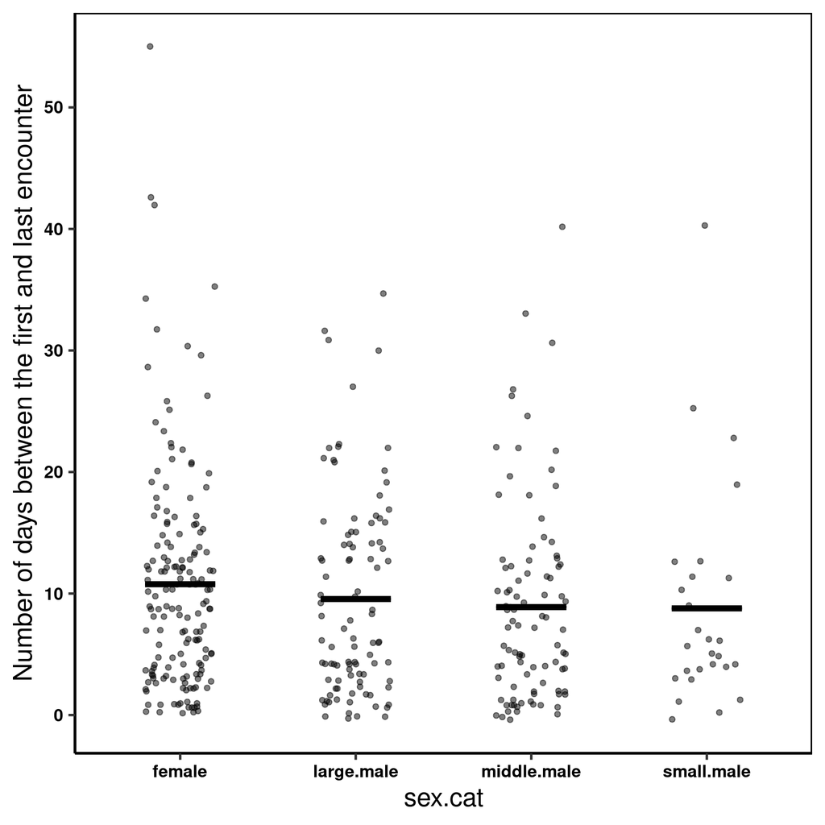

```r
new.plot2<-new.all.capt2[,c(5,12)]
new.plot2.sum<-aggregate(.~sex.cat,mean,data=new.plot2)



new2+ theme(plot.title.position = "plot")+geom_crossbar(data=new.plot2.sum, aes(ymin=days,ymax=days),size=0.8,width=0.4)
```

Lets see now the effect size:

```r
rsq.partial(new.nb.days1,type='kl')
```

```
## $adjustment
## [1] FALSE
##
## $variable
## [1] "sex.cat"       "no.recaptures"
##
## $partial.rsq
## [1] 0.01288945 0.06083691
```

Females and male morphs showed also a small effect size: 0.013.

```r
ph.test.days<-emmeans(new.nb.days1, ~sex.cat,type="response")
test(ph.test.days)
```

```
##  sex.cat     response    SE  df null z.ratio p.value
##  female         10.79 0.734 Inf    1  34.967  <.0001
##  large.male      8.72 0.781 Inf    1  24.192  <.0001
##  middle.male     8.62 0.783 Inf    1  23.711  <.0001
##  small.male      9.15 1.541 Inf    1  13.148  <.0001
##
## Tests are performed on the log scale
```

```r
pairs(ph.test.days)
```

```
##  contrast                 ratio    SE  df null z.ratio p.value
##  female / large.male      1.237 0.140 Inf    1   1.882  0.2360
##  female / middle.male     1.251 0.142 Inf    1   1.976  0.1971
##  female / small.male      1.179 0.214 Inf    1   0.905  0.8019
##  large.male / middle.male 1.012 0.129 Inf    1   0.092  0.9997
##  large.male / small.male  0.953 0.182 Inf    1  -0.252  0.9944
##  middle.male / small.male 0.942 0.180 Inf    1  -0.313  0.9893
##
## P value adjustment: tukey method for comparing a family of 4 estimates
## Tests are performed on the log scale
```

```r
contrast(ph.test.days)
```

```
##  contrast           ratio     SE  df null z.ratio p.value
##  female effect      1.162 0.0853 Inf    1   2.047  0.1628
##  large.male effect  0.940 0.0794 Inf    1  -0.736  0.6155
##  middle.male effect 0.929 0.0787 Inf    1  -0.873  0.6155
##  small.male effect  0.986 0.1296 Inf    1  -0.107  0.9150
##
## P value adjustment: fdr method for 4 tests
## Tests are performed on the log scale
```

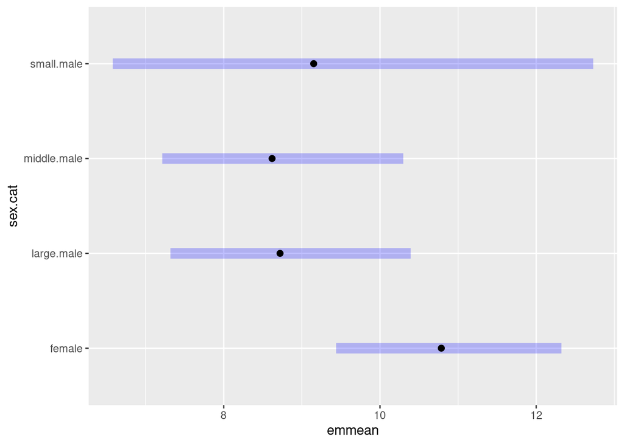

```r
plot(ph.test.days)
```

```r
ph.test.days2<-emmeans(new.nb.days1, ~sex.cat,type="link")
test(ph.test.days2)
```

```
##  sex.cat     emmean     SE  df z.ratio p.value
##  female        2.38 0.0680 Inf  34.967  <.0001
##  large.male    2.17 0.0895 Inf  24.192  <.0001
##  middle.male   2.15 0.0908 Inf  23.711  <.0001
##  small.male    2.21 0.1684 Inf  13.148  <.0001
##
## Results are given on the log (not the response) scale.
```

```r
pairs(ph.test.days2)
```

```
##  contrast                 estimate    SE  df z.ratio p.value
##  female - large.male        0.2125 0.113 Inf   1.882  0.2360
##  female - middle.male       0.2243 0.113 Inf   1.976  0.1971
##  female - small.male        0.1643 0.181 Inf   0.905  0.8019
##  large.male - middle.male   0.0118 0.128 Inf   0.092  0.9997
##  large.male - small.male   -0.0482 0.191 Inf  -0.252  0.9944
##  middle.male - small.male  -0.0600 0.191 Inf  -0.313  0.9893
##
## Results are given on the log (not the response) scale.
## P value adjustment: tukey method for comparing a family of 4 estimates
```

```r
contrast(ph.test.days2)
```

```
##  contrast           estimate     SE  df z.ratio p.value
##  female effect        0.1502 0.0734 Inf   2.047  0.1628
##  large.male effect   -0.0622 0.0845 Inf  -0.736  0.6155
##  middle.male effect  -0.0740 0.0848 Inf  -0.873  0.6155
##  small.male effect   -0.0140 0.1314 Inf  -0.107  0.9150
##
## Results are given on the log (not the response) scale.
## P value adjustment: fdr method for 4 tests
```

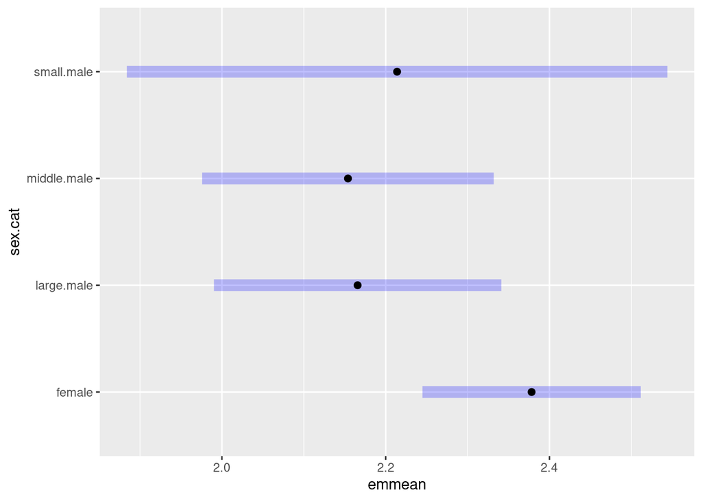

```r
plot(ph.test.days2)
```

#### New analyses of distances travelled between two encounters

Response variables: female-male categories (4-level factor), number of days since start of the study, number of days between two encounters, and id as a random factor.

```r
colnames(new.all.dist)
```

```
##  [1] "id"                 "no.cap"             "sex"
##  [4] "age"                "aktiv"              "date"
##  [7] "cap.recap"          "comment"            "x.coord"
## [10] "y.coord"            "elev.map.b"         "Distance"
## [13] "body"               "proc"               "date.of.catch"
## [16] "id.1"               "diff.days"          "rel.bodywidth"
## [19] "st.date"            "day"                "day.from.1st.catch"
## [22] "sex.cat"
```

```r
str(new.all.dist)
```

```
## 'data.frame':    683 obs. of  22 variables:
##  $ id                : int  3 35 37 37 46 48 48 55 55 55 ...
##  $ no.cap            : int  2 2 3 4 2 3 2 2 5 6 ...
##  $ sex               : chr  "f" "f" "f" "f" ...
##  $ age               : chr  "juvenil" "juvenil" "juvenil" "juvenil" ...
##  $ aktiv             : chr  "" "dig" "travelled" "travelled" ...
##  $ date              : chr  "2016-03-30" "2016-03-21" "2016-03-30" "2016-04-07" ...
##  $ cap.recap         : chr  "r" "r" "r" "r" ...
##  $ comment           : chr  "died" "" "" "" ...
##  $ x.coord           : num  738888 738823 738783 738782 738907 ...
##  $ y.coord           : num  326513 326586 326601 326608 326540 ...
##  $ elev.map.b        : num  221 244 248 248 225 ...
##  $ Distance          : num  1.69 2.02 9.4 6.79 5.44 ...
##  $ body              : num  12.1 12.2 10.7 10.7 10.7 ...
##  $ proc              : num  0 0 0 0 0 0 0 0 0 0 ...
##  $ date.of.catch     : chr  "2016-03-17" "2016-03-18" "2016-03-18" "2016-03-18" ...
##  $ id.1              : int  3 35 37 37 46 48 48 55 55 55 ...
##  $ diff.days         : num  13 3 12 8 42 9 1 8 1 1 ...
##  $ rel.bodywidth     : num  0.507 0.664 -1.484 -1.484 -1.512 ...
##  $ st.date           : chr  "2016-03-17" "2016-03-17" "2016-03-17" "2016-03-17" ...
##  $ day               : int  13 4 13 21 46 14 13 12 15 16 ...
##  $ day.from.1st.catch: int  0 1 1 1 4 4 4 4 4 4 ...
##  $ sex.cat           : chr  "female" "female" "female" "female" ...
```

```r
library(lme4)
dist.new<-lmer(log(Distance+1) ~ (sex.cat+day+diff.days)^2+(1|id),data=new.all.dist)
print(summary(dist.new),correlation=TRUE)
```

```
## Linear mixed model fit by REML ['lmerMod']
## Formula: log(Distance + 1) ~ (sex.cat + day + diff.days)^2 + (1 | id)
##    Data: new.all.dist
##
## REML criterion at convergence: 1966.2
##
## Scaled residuals:
##     Min      1Q  Median      3Q     Max
## -2.2784 -0.6082 -0.1600  0.4177  4.2676
##
## Random effects:
##  Groups   Name        Variance Std.Dev.
##  id       (Intercept) 0.1315   0.3627
##  Residual             0.8200   0.9055
## Number of obs: 683, groups:  id, 380
##
## Fixed effects:
##                                Estimate Std. Error t value
## (Intercept)                   1.9650226  0.1760181  11.164
## sex.catlarge.male            -0.5415786  0.2224427  -2.435
## sex.catmiddle.male           -0.5272243  0.2349729  -2.244
## sex.catsmall.male             0.2057122  0.3520160   0.584
## day                          -0.0122287  0.0049917  -2.450
## diff.days                     0.0132941  0.0206689   0.643
## sex.catlarge.male:day         0.0136637  0.0074487   1.834
## sex.catmiddle.male:day        0.0261981  0.0083567   3.135
## sex.catsmall.male:day         0.0038805  0.0127208   0.305
## sex.catlarge.male:diff.days   0.0141152  0.0171904   0.821
## sex.catmiddle.male:diff.days  0.0149003  0.0175390   0.850
## sex.catsmall.male:diff.days   0.0229621  0.0254438   0.902
## day:diff.days                 0.0006018  0.0004213   1.429
```

```
##
## Correlation of fixed effects could have been required in summary()
```

```
##
## Correlation of Fixed Effects:
##             (Intr) sx.ctl. sx.ctm. sx.cts. day    dff.dy sx.ctl.: sx.ctm.:
## sx.ctlrg.ml -0.645
## sx.ctmddl.m -0.535  0.413
## sx.ctsmll.m -0.393  0.287   0.260
## day         -0.847  0.529   0.427   0.320
## diff.days   -0.526  0.186   0.055   0.095   0.321
## sx.ctlrg.m:  0.401 -0.782  -0.274  -0.187  -0.509  0.047
## sx.ctmddl.:  0.277 -0.240  -0.787  -0.154  -0.376  0.169  0.275
## sx.ctsmll.:  0.267 -0.186  -0.163  -0.774  -0.329 -0.023  0.191    0.157
## sx.ctlrg.:.  0.183 -0.090  -0.034  -0.041   0.049 -0.496 -0.370   -0.139
## sx.ctmdd.:.  0.163 -0.069  -0.006  -0.037   0.064 -0.458 -0.112   -0.453
## sx.ctsml.:. -0.035  0.002  -0.012   0.098   0.187 -0.086 -0.096   -0.071
## day:dff.dys  0.563 -0.187  -0.040  -0.092  -0.546 -0.887  0.071   -0.080
##             sx.cts.: sx.ctl.:. sx.ctm.:. sx.cts.:.
## sx.ctlrg.ml
## sx.ctmddl.m
## sx.ctsmll.m
## day
## diff.days
## sx.ctlrg.m:
## sx.ctmddl.:
## sx.ctsmll.:
## sx.ctlrg.:. -0.050
## sx.ctmdd.:. -0.052    0.366
## sx.ctsml.:. -0.545    0.182     0.181
## day:dff.dys  0.098    0.269     0.233    -0.099
```

```r
drop1(dist.new,test="Chisq")
```

```
## Single term deletions
##
## Model:
## log(Distance + 1) ~ (sex.cat + day + diff.days)^2 + (1 | id)
##                   npar    AIC     LRT Pr(Chi)
## <none>                 1910.4
## sex.cat:day          3 1915.5 11.1224 0.01108 *
## sex.cat:diff.days    3 1905.9  1.5602 0.66844
## day:diff.days        1 1910.4  2.0351 0.15371
## ---
## Signif. codes:  0 '***' 0.001 '**' 0.01 '*' 0.05 '.' 0.1 ' ' 1
```

```r
dist.new2<-update(dist.new,.~.-sex.cat:diff.days)
summary(dist.new2)
```

```
## Linear mixed model fit by REML ['lmerMod']
## Formula:
## log(Distance + 1) ~ sex.cat + day + diff.days + (1 | id) + sex.cat:day +
##     day:diff.days
##    Data: new.all.dist
##
## REML criterion at convergence: 1949.5
##
## Scaled residuals:
##     Min      1Q  Median      3Q     Max
## -2.3829 -0.6105 -0.1578  0.4239  4.3603
##
## Random effects:
##  Groups   Name        Variance Std.Dev.
##  id       (Intercept) 0.1346   0.3669
##  Residual             0.8155   0.9031
## Number of obs: 683, groups:  id, 380
##
## Fixed effects:
##                          Estimate Std. Error t value
## (Intercept)             1.9376801  0.1715472  11.295
## sex.catlarge.male      -0.5220218  0.2214644  -2.357
## sex.catmiddle.male     -0.5191325  0.2349270  -2.210
## sex.catsmall.male       0.1963722  0.3496516   0.562
## day                    -0.0131841  0.0049007  -2.690
## diff.days               0.0246196  0.0168212   1.464
## sex.catlarge.male:day   0.0159671  0.0069115   2.310
## sex.catmiddle.male:day  0.0292316  0.0074463   3.926
## sex.catsmall.male:day   0.0094998  0.0106371   0.893
## day:diff.days           0.0005248  0.0003943   1.331
##
## Correlation of Fixed Effects:
##             (Intr) sx.ctl. sx.ctm. sx.cts. day    dff.dy sx.ctl.: sx.ctm.:
## sx.ctlrg.ml -0.643
## sx.ctmddl.m -0.544  0.412
## sx.ctsmll.m -0.387  0.284   0.261
## day         -0.885  0.544   0.437   0.311
## diff.days   -0.505  0.159   0.050   0.077   0.441
## sx.ctlrg.m:  0.513 -0.881  -0.310  -0.215  -0.534 -0.169
## sx.ctmddl.:  0.401 -0.304  -0.886  -0.193  -0.399 -0.040  0.285
## sx.ctsmll.:  0.288 -0.215  -0.201  -0.863  -0.279 -0.053  0.201    0.185
## day:dff.dys  0.531 -0.164  -0.035  -0.063  -0.583 -0.921  0.185    0.025
##             sx.cts.:
## sx.ctlrg.ml
## sx.ctmddl.m
## sx.ctsmll.m
## day
## diff.days
## sx.ctlrg.m:
## sx.ctmddl.:
## sx.ctsmll.:
## day:dff.dys  0.031
```

```r
drop1(dist.new2,test="Chisq")
```

```
## Single term deletions
##
## Model:
## log(Distance + 1) ~ sex.cat + day + diff.days + (1 | id) + sex.cat:day +
##     day:diff.days
##               npar    AIC     LRT   Pr(Chi)
## <none>             1905.9
## sex.cat:day      3 1917.0 17.0245 0.0006986 ***
## day:diff.days    1 1905.7  1.7496 0.1859264
## ---
## Signif. codes:  0 '***' 0.001 '**' 0.01 '*' 0.05 '.' 0.1 ' ' 1
```

```r
dist.new3<-update(dist.new2,.~.-day:diff.days)
summary(dist.new3)
```

```
## Linear mixed model fit by REML ['lmerMod']
## Formula: log(Distance + 1) ~ sex.cat + day + diff.days + (1 | id) + sex.cat:day
##    Data: new.all.dist
##
## REML criterion at convergence: 1937.4
##
## Scaled residuals:
##     Min      1Q  Median      3Q     Max
## -2.1931 -0.6125 -0.1508  0.4223  4.2399
##
## Random effects:
##  Groups   Name        Variance Std.Dev.
##  id       (Intercept) 0.1297   0.3601
##  Residual             0.8204   0.9058
## Number of obs: 683, groups:  id, 380
##
## Fixed effects:
##                         Estimate Std. Error t value
## (Intercept)             1.817707   0.145043  12.532
## sex.catlarge.male      -0.476567   0.217994  -2.186
## sex.catmiddle.male     -0.510190   0.234366  -2.177
## sex.catsmall.male       0.223468   0.348234   0.642
## day                    -0.009409   0.003978  -2.365
## diff.days               0.045297   0.006559   6.906
## sex.catlarge.male:day   0.014298   0.006786   2.107
## sex.catmiddle.male:day  0.028992   0.007438   3.898
## sex.catsmall.male:day   0.009084   0.010619   0.855
##
## Correlation of Fixed Effects:
##             (Intr) sx.ctl. sx.ctm. sx.cts. day    dff.dy sx.ctl.: sx.ctm.:
## sx.ctlrg.ml -0.665
## sx.ctmddl.m -0.620  0.412
## sx.ctsmll.m -0.418  0.278   0.260
## day         -0.836  0.559   0.513   0.339
## diff.days   -0.047  0.022   0.044   0.050  -0.303
## sx.ctlrg.m:  0.498 -0.878  -0.308  -0.207  -0.533  0.003
## sx.ctmddl.:  0.458 -0.304  -0.886  -0.192  -0.473 -0.044  0.285
## sx.ctsmll.:  0.321 -0.213  -0.200  -0.863  -0.321 -0.062  0.199    0.185
```

```r
drop1(dist.new3,test="Chisq")
```

```
## Single term deletions
##
## Model:
## log(Distance + 1) ~ sex.cat + day + diff.days + (1 | id) + sex.cat:day
##             npar    AIC    LRT   Pr(Chi)
## <none>           1905.7
## diff.days      1 1950.1 46.440 9.446e-12 ***
## sex.cat:day    3 1916.0 16.319 0.0009755 ***
## ---
## Signif. codes:  0 '***' 0.001 '**' 0.01 '*' 0.05 '.' 0.1 ' ' 1
```

Compare “stats drop1” to “glmmTMB drop1”:

```r
library(glmmTMB)
dist.new.tmb<-glmmTMB(log(Distance+1) ~ sex.cat:day+diff.days+(1|id),family="gaussian",data=new.all.dist)
summary(dist.new.tmb)
```

```
##  Family: gaussian  ( identity )
## Formula:          log(Distance + 1) ~ sex.cat:day + diff.days + (1 | id)
## Data: new.all.dist
##
##      AIC      BIC   logLik deviance df.resid
##   1908.8   1945.0   -946.4   1892.8      675
##
## Random effects:
##
## Conditional model:
##  Groups   Name        Variance Std.Dev.
##  id       (Intercept) 0.1474   0.3839
##  Residual             0.8065   0.8981
## Number of obs: 683, groups:  id, 380
##
## Dispersion estimate for gaussian family (sigma^2): 0.806
##
## Conditional model:
##                         Estimate Std. Error z value Pr(>|z|)
## (Intercept)             1.571437   0.090254  17.411  < 2e-16 ***
## diff.days               0.045330   0.006582   6.887 5.72e-12 ***
## sex.catfemale:day      -0.003732   0.003021  -1.235  0.21665
## sex.catlarge.male:day  -0.001990   0.004039  -0.493  0.62214
## sex.catmiddle.male:day  0.011525   0.004276   2.695  0.00703 **
## sex.catsmall.male:day   0.012332   0.005844   2.110  0.03486 *
## ---
## Signif. codes:  0 '***' 0.001 '**' 0.01 '*' 0.05 '.' 0.1 ' ' 1
```

```r
drop1(dist.new.tmb,test="Chisq")
```

```
## Single term deletions
##
## Model:
## log(Distance + 1) ~ sex.cat:day + diff.days + (1 | id)
##             Df    AIC    LRT  Pr(>Chi)
## <none>         1908.8
## diff.days    1 1952.6 45.761 1.336e-11 ***
## sex.cat:day  4 1926.8 26.011 3.148e-05 ***
## ---
## Signif. codes:  0 '***' 0.001 '**' 0.01 '*' 0.05 '.' 0.1 ' ' 1
```

```r
ph.dist.new<-emmeans::emtrends(dist.new3,~1,"diff.days")
test(ph.dist.new)
```

```
##  1       diff.days.trend      SE  df t.ratio p.value
##  overall          0.0453 0.00657 670   6.894  <.0001
##
## Results are averaged over the levels of: sex.cat
## Degrees-of-freedom method: kenward-roger
```

```
## Using data new.all.dist from global environment. This could cause incorrect
## results if new.all.dist has been altered since the model was fit. You can
## manually provide the data to the "data =" argument.
```

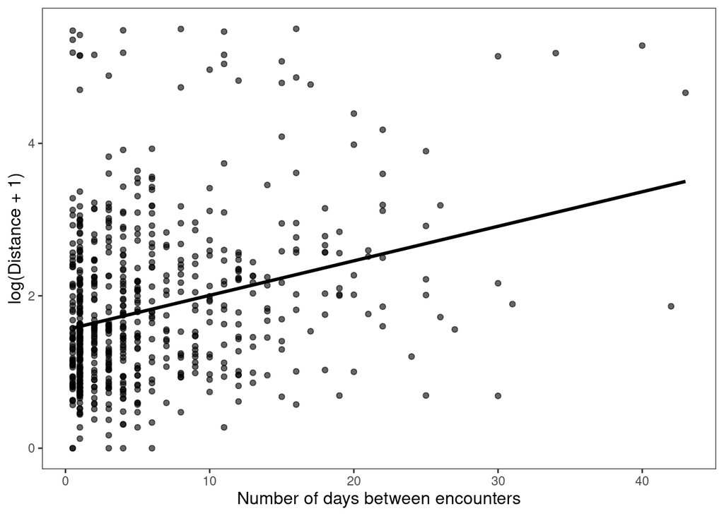

```r
effect_plot(dist.new3, pred = diff.days, interval = FALSE, plot.points = TRUE,x.label="Number of days between encounters")+ theme_apa()
```

```r
ph.dist.new2<-emtrends(dist.new3,~sex.cat,"day")
test(ph.dist.new2)
```

```
##  sex.cat     day.trend      SE  df t.ratio p.value
##  female      -0.009409 0.00399 523  -2.360  0.0187
##  large.male   0.004889 0.00576 548   0.848  0.3968
##  middle.male  0.019582 0.00659 580   2.974  0.0031
##  small.male  -0.000326 0.01009 477  -0.032  0.9743
##
## Degrees-of-freedom method: kenward-roger
```

```r
pairs(ph.dist.new2)
```

[output not shown]

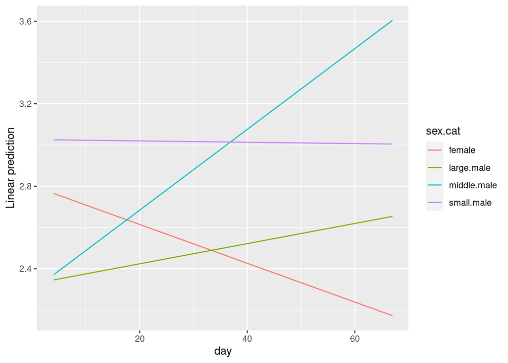

```r
emmip(dist.new3,sex.cat~day,cov.reduce=range)
```

Small males seem to travel and move similarly to the females.

Lets visualise the results.

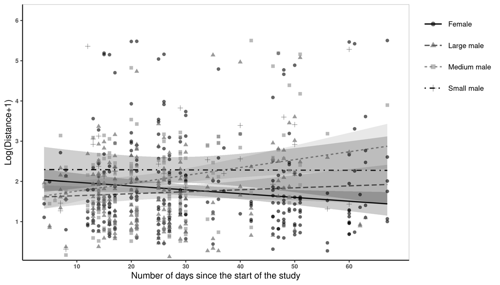

```r
new.dist1<-interact_plot(dist.new3, pred = day, modx = sex.cat,x.label="Number of days since the start of the study",data=new.all.dist,y.label="Log(Distance+1)",lwd=2,line.thickness=1.2,colors=c("black","grey35","grey55","grey6"),plot.points=TRUE,point.shape=T,point.size=3,interval = TRUE,  int.type = "confidence", int.width = .95,modx.labels=c("Female","Large male","Medium male","Small male")) + theme_apa()+theme_classic(base_size = 18)+theme(legend.title=element_blank(),legend.key.size = unit(3, "lines"),legend.position="right",legend.justification = "top")+guides(fill = guide_legend(override.aes = list(size=4)))+ scale_x_continuous(limits=c(0.04,71),expand=c(0,0),breaks=c(10,20,30,40,50,60)) + scale_y_continuous(limits=c(0.04,6.4), expand=c(0,0),breaks=c(1,2,3,4,5,6))



new.dist1 + theme (axis.text.x = element_text(face = "bold", size=12),  axis.text.y = element_text(face = "bold", size = 12),panel.border = element_rect(colour = "black", fill=NA, size=0.2))
```

Create colourfull plots for graphical abstract:

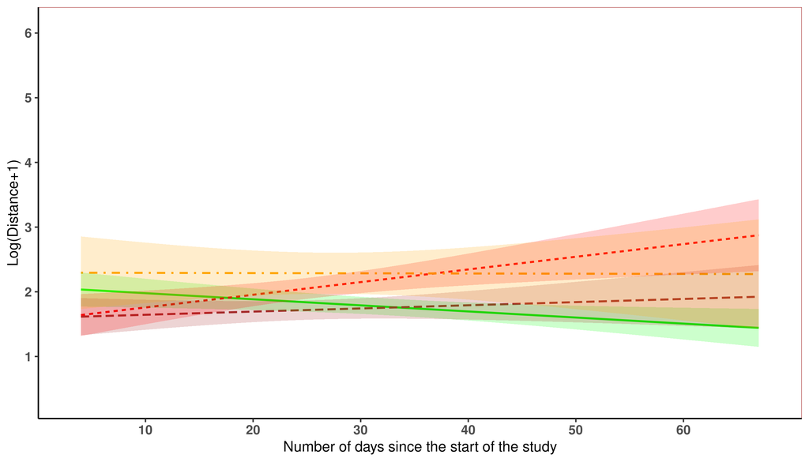

```r
new.dist.col<-interact_plot(dist.new3, pred = day, modx = sex.cat,x.label="Number of days since the start of the study",data=new.all.dist,y.label="Log(Distance+1)",lwd=2,line.thickness=1.2,colors=c("green","brown","red","orange"),interval = TRUE, int.type = "confidence", int.width = .95) + theme_apa()+theme_classic(base_size = 18)+ scale_x_continuous(limits=c(0.04,71),expand=c(0,0),breaks=c(10,20,30,40,50,60)) + scale_y_continuous(limits=c(0.04,6.4), expand=c(0,0),breaks=c(1,2,3,4,5,6))+theme(legend.position = "none")



new.dist.col + theme (axis.text.x = element_text(face = "bold", size=16),  axis.text.y = element_text(face = "bold", size = 16),panel.border = element_rect(colour = "brown", fill=NA, size=0.5))
```

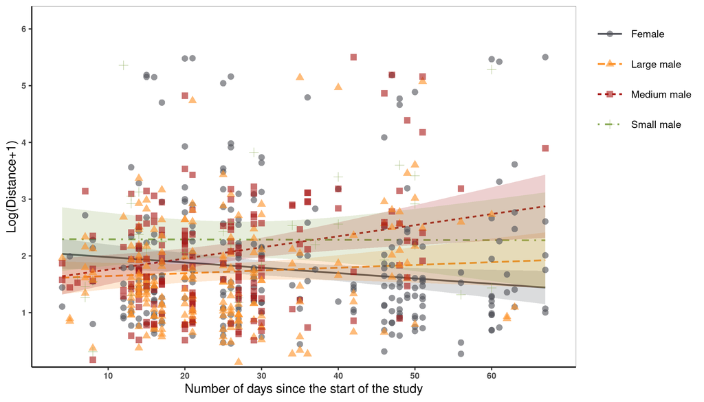

```r
new.dist.col2<-interact_plot(dist.new3, pred = day, modx = sex.cat,x.label="Number of days since the start of the study",data=new.all.dist,y.label="Log(Distance+1)",lwd=2,line.thickness=1.2,colors=c("#4f5157","#fd8f24","#a81816","#89a954"),plot.points=TRUE,point.shape=T,point.size=4,interval = TRUE,  int.type = "confidence", int.width = .95,modx.labels=c("Female","Large male","Medium male","Small male")) + theme_apa()+theme_classic(base_size = 18)+theme(legend.title=element_blank(),legend.key.size = unit(3, "lines"),legend.position="right",legend.justification = "top")+guides(fill = guide_legend(override.aes = list(size=4)))+ scale_x_continuous(limits=c(0.04,71),expand=c(0,0),breaks=c(10,20,30,40,50,60)) + scale_y_continuous(limits=c(0.04,6.4), expand=c(0,0),breaks=c(1,2,3,4,5,6))



new.dist.col2 + theme (axis.text.x = element_text(face = "bold", size=12),  axis.text.y = element_text(face = "bold", size = 12),panel.border = element_rect(colour = "black", fill=NA, size=0.2))
```

```r
ggsave("seasonal.movement.Figure.1.tiff", units="px",height= 3000, width= 4000,dpi=300)
```

Lets see effect sizes:

```r
partR2(dist.new3, partvars= c("diff.days","sex.cat:day"),R2_type="conditional",nboot = 100, CI = 0.95)
```

```
##
##
## R2 (conditional) and 95% CI for the full model:
##  R2     CI_lower CI_upper nboot ndf
##  0.2483 0.1788   0.3563   100   9
##
## ----------
##
## Part (semi-partial) R2:
##  Predictor(s)          R2     CI_lower CI_upper nboot ndf
##  Model                 0.2483 0.1788   0.3563   100   9
##  diff.days             0.1808 0.1095   0.2906   100   8
##  sex.cat:day           0.1395 0.0671   0.2506   100   6
##  diff.days+sex.cat:day 0.2039 0.1332   0.3130   100   5
```

```r
partR2(dist.new3, partvars= c("diff.days","sex.cat:day"),R2_type="marginal",nboot = 100, CI = 0.95)
```

```
##
##
## R2 (marginal) and 95% CI for the full model:
##  R2     CI_lower CI_upper nboot ndf
##  0.1295 0.0982   0.1909   100   9
##
## ----------
##
## Part (semi-partial) R2:
##  Predictor(s)          R2     CI_lower CI_upper nboot ndf
##  Model                 0.1295 0.0982   0.1909   100   9
##  diff.days             0.0619 0.0280   0.1269   100   8
##  sex.cat:day           0.0207 0.0000   0.0877   100   6
##  diff.days+sex.cat:day 0.0850 0.0520   0.1489   100   5
```

Lets create a plot for the first two models:

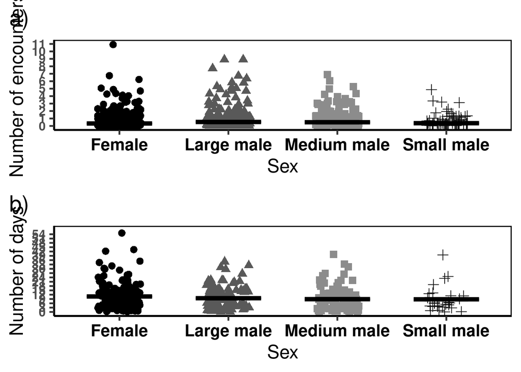

```r
d.plot1<-new.all.capt[,c(7,12)]
d.plot1.sum<-aggregate(.~sex.cat,mean,data=d.plot1)

p1new<-ggplot(d.plot1,aes(sex.cat,no.recaptures),line.thickness=1.2) +theme_classic(base_size = 18)+geom_point(position=position_jitter(width=0.2),size=3,aes(shape=sex.cat,x = sex.cat, y = no.recaptures,color=sex.cat))+
scale_y_continuous(name="Number of encounters",limits=c(0,11),breaks= round(seq(min(new.all.capt$no.recaptures),max(new.all.capt$no.recaptures),by=1),1)) +  labs(x="Sex")+scale_x_discrete(labels=c("Female","Large male","Medium male", "Small male"))+theme (axis.text.x = element_text(face = "bold", size=16,colour="black"), axis.text.y = element_text(face = "bold", size = 12),panel.border= element_rect(color ="black",fill=NA,size=1))+geom_crossbar(data=d.plot1.sum, aes(ymin=no.recaptures,ymax=no.recaptures),size=0.8,width=0.6)+theme(legend.position = "none")+ scale_color_manual(values = c("black","grey35","grey55","grey6"))

p1t<-p1new+labs(title = "a)") + theme(plot.title.position = "plot")+geom_crossbar(data=d.plot1.sum, aes(ymin=no.recaptures,ymax=no.recaptures),size=0.8,width=0.4)

d.plot<-new.all.capt2[,c(5,12)]
d.plot.sum<-aggregate(.~sex.cat,mean,data=d.plot)

p2<-ggplot(d.plot,aes(sex.cat,days),line.thickness=1.2) +theme_classic(base_size = 18)+geom_point(position=position_jitter(width=0.2),size=3,aes(shape=sex.cat,x = sex.cat, y = days, color = sex.cat))+
scale_y_continuous(name="Number of days",limits=c(0,57),breaks= round(seq(min(new.all.capt2$days),max(new.all.capt2$days),by=3),1)) +  labs(x="Sex")+scale_x_discrete(labels=c("Female","Large male","Medium male", "Small male"))+theme (axis.text.x = element_text(face = "bold", size=16,colour="black"), axis.text.y = element_text(face = "bold", size = 12),panel.border= element_rect(color ="black",fill=NA,size=1))+geom_crossbar(data=d.plot.sum, aes(ymin=days,ymax=days),size=0.8,width=0.6)+theme(legend.position = "none")+ scale_color_manual(values = c("black","grey35","grey55","grey6"))


p2t<-p2+labs(title = "b)") + theme(plot.title.position = "plot")+geom_crossbar(data=d.plot.sum, aes(ymin=days,ymax=days),size=0.8,width=0.4)

library(gridExtra)
grid.arrange(p1t, p2t, nrow=2)
```

```r
table(new.all.capt$sex.cat,new.all.capt$no.recaptures)
```

```
##
##                 0   1   2   3   4   5   6   7   8   9  11
##   female      626 118  24   8   5   3   1   1   0   0   2
##   large.male  298  56  16   7   4   7   3   1   1   2   0
##   middle.male 237  58  14  13   4   2   1   1   0   0   0
##   small.male   84  19   4   3   0   1   0   0   0   0   0
```

### New analyses of males’ movement

Because of critics, lets see what if we use body size and tusk length as a continuous variable in our models:

```r
str(all.capt)
```

```
## 'data.frame':    1624 obs. of  11 variables:
##  $ ID           : int  3 35 37 46 48 55 57 68 72 92 ...
##  $ sex          : chr  "f" "f" "f" "f" ...
##  $ B.width      : num  12.1 12.2 10.7 10.7 11.7 ...
##  $ Tusk         : num  0 0 0 0 0 0 0 0 0 0 ...
##  $ days         : int  13 3 20 42 10 23 22 26 8 43 ...
##  $ Age          : chr  "juvenil" "juvenil" "juvenil" "juvenil" ...
##  $ no.recaptures: int  1 1 2 1 2 6 11 2 2 1 ...
##  $ tot.dist     : num  1.69 2.02 16.19 5.44 5.09 ...
##  $ max.dist     : num  1.69 2.02 9.4 5.44 2.81 ...
##  $ dist.a.day   : num  0.13 0.675 0.81 0.13 0.509 ...
##  $ rel.bodywidth: num  0.492 0.65 -1.51 -1.538 -0.051 ...
```

```r
str(all.dist)
```

```
## 'data.frame':    683 obs. of  21 variables:
##  $ id                : int  3 35 37 37 46 48 48 55 55 55 ...
##  $ no.cap            : int  2 2 3 4 2 3 2 2 5 6 ...
##  $ sex               : chr  "f" "f" "f" "f" ...
##  $ age               : chr  "juvenil" "juvenil" "juvenil" "juvenil" ...
##  $ aktiv             : chr  "" "dig" "travelled" "travelled" ...
##  $ date              : chr  "2016-03-30" "2016-03-21" "2016-03-30" "2016-04-07" ...
##  $ cap.recap         : chr  "r" "r" "r" "r" ...
##  $ comment           : chr  "died" "" "" "" ...
##  $ x.coord           : num  738888 738823 738783 738782 738907 ...
##  $ y.coord           : num  326513 326586 326601 326608 326540 ...
##  $ elev.map.b        : num  221 244 248 248 225 ...
##  $ Distance          : num  1.69 2.02 9.4 6.79 5.44 ...
##  $ body              : num  12.1 12.2 10.7 10.7 10.7 ...
##  $ proc              : num  0 0 0 0 0 0 0 0 0 0 ...
##  $ date.of.catch     : chr  "2016-03-17" "2016-03-18" "2016-03-18" "2016-03-18" ...
##  $ id.1              : int  3 35 37 37 46 48 48 55 55 55 ...
##  $ diff.days         : num  13 3 12 8 42 9 1 8 1 1 ...
##  $ rel.bodywidth     : num  0.507 0.664 -1.484 -1.484 -1.512 ...
##  $ st.date           : chr  "2016-03-17" "2016-03-17" "2016-03-17" "2016-03-17" ...
##  $ day               : int  13 4 13 21 46 14 13 12 15 16 ...
##  $ day.from.1st.catch: int  0 1 1 1 4 4 4 4 4 4 ...
```

```r
str(new.all.capt.m)
```

```
## 'data.frame':    835 obs. of  12 variables:
##  $ ID           : int  6 14 17 36 38 49 50 52 56 65 ...
##  $ sex          : chr  "m" "m" "m" "m" ...
##  $ B.width      : num  13.7 13.6 13 13.1 11.6 ...
##  $ Tusk         : num  4.58 4.11 4.13 4.06 3.4 3.72 1.81 2.36 3.81 3.8 ...
##  $ days         : int  21 7 4 16 16 1 4 31 4 10 ...
##  $ Age          : chr  "juvenil" "juvenil" "juvenil" "juvenil" ...
##  $ no.recaptures: int  2 1 1 1 1 2 3 7 2 1 ...
##  $ tot.dist     : num  116.13 2.83 6.11 5.14 6.53 ...
##  $ max.dist     : num  112.84 2.83 6.11 5.14 6.53 ...
##  $ dist.a.day   : num  5.53 0.404 1.526 0.322 0.408 ...
##  $ rel.bodywidth: num  1.671 1.559 0.867 0.923 -0.662 ...
##  $ sex.cat      : chr  "large.male" "large.male" "large.male" "large.male" ...
```

```r
new.all.capt.m$proc.rat<-new.all.capt.m$Tusk/new.all.capt.m$B.width

new.all.dist.m<-new.all.dist[new.all.dist$sex=="m",]

new.all.dist.m<-new.all.dist[new.all.dist$proc>0,]

new.all.dist.m
```

[output not shown]

[output cut: 1242 more lines]

#### New analysis of number of recaptures

Lets see the models:

```r
new.male.rec.nb<-glm.nb(no.recaptures~proc.rat,new.all.capt.m)
summary(new.male.rec.nb)
```

```
##
## Call:
## glm.nb(formula = no.recaptures ~ proc.rat, data = new.all.capt.m,
##     init.theta = 0.3192995937, link = log)
##
## Coefficients:
##             Estimate Std. Error z value Pr(>|z|)
## (Intercept)  -1.3937     0.3251  -4.287 1.81e-05 ***
## proc.rat      2.7784     1.2581   2.208   0.0272 *
## ---
## Signif. codes:  0 '***' 0.001 '**' 0.01 '*' 0.05 '.' 0.1 ' ' 1
##
## (Dispersion parameter for Negative Binomial(0.3193) family taken to be 1)
##
##     Null deviance: 540.98  on 833  degrees of freedom
## Residual deviance: 536.33  on 832  degrees of freedom
##   (1 observation deleted due to missingness)
## AIC: 1524.9
##
## Number of Fisher Scoring iterations: 1
##
##
##               Theta:  0.3193
##           Std. Err.:  0.0405
##
##  2 x log-likelihood:  -1518.8610
```

```r
drop1(new.male.rec.nb,test="Chisq")
```

```
## Single term deletions
##
## Model:
## no.recaptures ~ proc.rat
##          Df Deviance    AIC    LRT Pr(>Chi)
## <none>        536.33 1522.9
## proc.rat  1   540.98 1525.5 4.6554  0.03096 *
## ---
## Signif. codes:  0 '***' 0.001 '**' 0.01 '*' 0.05 '.' 0.1 ' ' 1
```

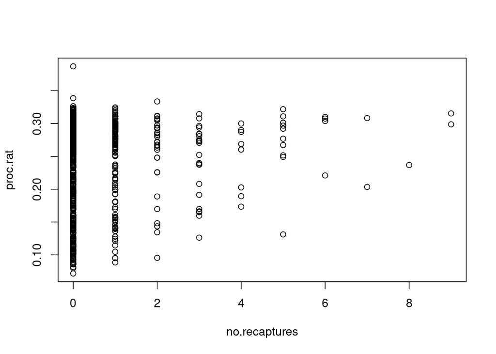

```r
plot(proc.rat~no.recaptures,new.all.capt.m)
```

```r
male.capt<-emtrends(new.male.rec.nb,~1,"proc.rat")
test(male.capt)
```

```
##  1       proc.rat.trend   SE  df z.ratio p.value
##  overall           2.78 1.26 Inf   2.208  0.0272
```

Lets see the effect size

```r
rsq.partial(new.male.rec.nb,type='kl')
```

```
## $adjustment
## [1] FALSE
##
## $variable
## [1] "proc.rat"
##
## $partial.rsq
## [1] 0.008605398
```

#### New analysis of number of days between the first and last encounter

```r
new.all.capt.m2<-new.all.capt.m[new.all.capt.m$no.recaptures>0,]

new.male.day.nb<-glm.nb(days~proc.rat,new.all.capt.m2)
summary(new.male.day.nb)
```

```
##
## Call:
## glm.nb(formula = days ~ proc.rat, data = new.all.capt.m2, init.theta = 1.281206426,
##     link = log)
##
## Coefficients:
##             Estimate Std. Error z value Pr(>|z|)
## (Intercept)   2.2341     0.2733   8.173    3e-16 ***
## proc.rat     -0.0740     1.0561  -0.070    0.944
## ---
## Signif. codes:  0 '***' 0.001 '**' 0.01 '*' 0.05 '.' 0.1 ' ' 1
##
## (Dispersion parameter for Negative Binomial(1.2812) family taken to be 1)
##
##     Null deviance: 244.48  on 216  degrees of freedom
## Residual deviance: 244.47  on 215  degrees of freedom
##   (1 observation deleted due to missingness)
## AIC: 1419.4
##
## Number of Fisher Scoring iterations: 1
##
##
##               Theta:  1.281
##           Std. Err.:  0.141
##
##  2 x log-likelihood:  -1413.361
```

```r
drop1(new.male.day.nb,test="Chisq")
```

```
## Single term deletions
##
## Model:
## days ~ proc.rat
##          Df Deviance    AIC       LRT Pr(>Chi)
## <none>        244.47 1417.4
## proc.rat  1   244.48 1415.4 0.0047871   0.9448
```

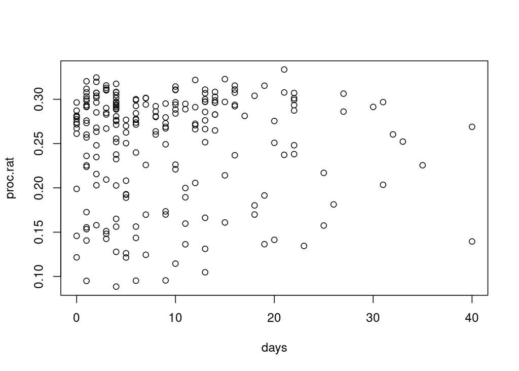

```r
plot(proc.rat~days,new.all.capt.m2)
```

#### New analysis of total travelled distance

```r
new.male.dist<-lm(log(tot.dist+1)~proc.rat*no.recaptures,new.all.capt.m2)
drop1(new.male.dist,test="F")
```

```
## Single term deletions
##
## Model:
## log(tot.dist + 1) ~ proc.rat * no.recaptures
##                        Df Sum of Sq    RSS     AIC F value Pr(>F)
## <none>                              190.97 -19.731
## proc.rat:no.recaptures  1 0.0051707 190.97 -21.725  0.0058 0.9395
```

```r
new.male.dist2<-update(new.male.dist,.~.-proc.rat:no.recaptures)
summary(new.male.dist2)
```

```
##
## Call:
## lm(formula = log(tot.dist + 1) ~ proc.rat + no.recaptures, data = new.all.capt.m2)
##
## Residuals:
##     Min      1Q  Median      3Q     Max
## -2.7595 -0.5663 -0.0818  0.4678  3.2141
##
## Coefficients:
##               Estimate Std. Error t value Pr(>|t|)
## (Intercept)    2.96430    0.27919  10.617  < 2e-16 ***
## proc.rat      -3.40890    1.06278  -3.208  0.00154 **
## no.recaptures  0.20960    0.04143   5.059 9.07e-07 ***
## ---
## Signif. codes:  0 '***' 0.001 '**' 0.01 '*' 0.05 '.' 0.1 ' ' 1
##
## Residual standard error: 0.9447 on 214 degrees of freedom
##   (1 observation deleted due to missingness)
## Multiple R-squared:  0.134,  Adjusted R-squared:  0.1259
## F-statistic: 16.56 on 2 and 214 DF,  p-value: 2.062e-07
```

```r
drop1(new.male.dist2,test="F")
```

```
## Single term deletions
##
## Model:
## log(tot.dist + 1) ~ proc.rat + no.recaptures
##               Df Sum of Sq    RSS      AIC F value    Pr(>F)
## <none>                     190.97 -21.7247
## proc.rat       1    9.1813 200.16 -13.5351  10.288  0.001544 **
## no.recaptures  1   22.8373 213.81   0.7869  25.591 9.066e-07 ***
## ---
## Signif. codes:  0 '***' 0.001 '**' 0.01 '*' 0.05 '.' 0.1 ' ' 1
```

```r
tot.dist.ph<-emtrends(new.male.dist2,~1,"proc.rat")
test(tot.dist.ph)
```

```
##  1       proc.rat.trend   SE  df t.ratio p.value
##  overall          -3.41 1.06 214  -3.208  0.0015
```

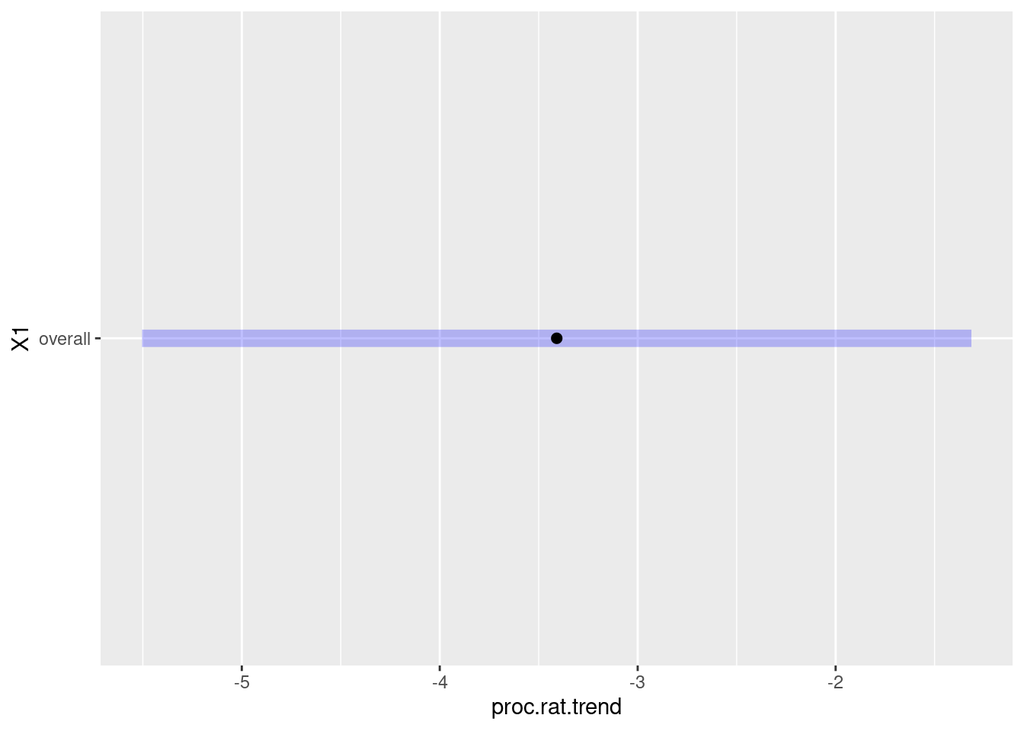

```r
plot(tot.dist.ph)
```

```r
tot.dist.ph2<-emmeans(new.male.dist2,~no.recaptures)
test(tot.dist.ph2)
```

```
##  no.recaptures emmean     SE  df t.ratio p.value
##           1.92   2.51 0.0641 214  39.113  <.0001
##
## Results are given on the log(mu + 1) (not the response) scale.
```

#### New analysis of daily travelled distance

```r
summary(new.all.capt.m2$tot.dist)
```

```
##    Min. 1st Qu.  Median    Mean 3rd Qu.    Max.    NA's
##   0.000   5.472  11.360  21.618  20.327 243.918       1
```

```r
summary(new.all.capt.m2$dist.a.day)
```

```
##    Min. 1st Qu.  Median    Mean 3rd Qu.    Max.    NA's
## 0.09128 0.75740 1.61833     Inf 4.80954     Inf       2
```

```r
new.male.dist.d<-lm(log(tot.dist+1)/(days+1)~proc.rat*no.recaptures,
                    new.all.capt.m2)
drop1(new.male.dist,test="F")
```

```
## Single term deletions
##
## Model:
## log(tot.dist + 1) ~ proc.rat * no.recaptures
##                        Df Sum of Sq    RSS     AIC F value Pr(>F)
## <none>                              190.97 -19.731
## proc.rat:no.recaptures  1 0.0051707 190.97 -21.725  0.0058 0.9395
```

```r
new.male.dist.d2<-update(new.male.dist.d,.~.-proc.rat:no.recaptures)
drop1(new.male.dist.d2,test="F")
```

```
## Single term deletions
##
## Model:
## log(tot.dist + 1)/(days + 1) ~ proc.rat + no.recaptures
##               Df Sum of Sq    RSS     AIC F value   Pr(>F)
## <none>                     70.601 -237.66
## proc.rat       1   0.33546 70.936 -238.63  1.0168 0.314416
## no.recaptures  1   2.35601 72.957 -232.54  7.1414 0.008113 **
## ---
## Signif. codes:  0 '***' 0.001 '**' 0.01 '*' 0.05 '.' 0.1 ' ' 1
```

Lets build the mixed model and use distances between two encounters as a response variable

```r
new.all.dist.m$proc.rat<-new.all.dist.m$proc/new.all.dist.m$body

library(glmmTMB)
dist.new.m.tmb<-glmmTMB(log(Distance+1) ~ (proc.rat*day)^2+diff.days+(1|id),family="gaussian",data=new.all.dist.m)
summary(dist.new.m.tmb)
```

```
##  Family: gaussian  ( identity )
## Formula:          log(Distance + 1) ~ (proc.rat * day)^2 + diff.days + (1 | id)
## Data: new.all.dist.m
##
##      AIC      BIC   logLik deviance df.resid
##   1066.7   1095.0   -526.4   1052.7      411
##
## Random effects:
##
## Conditional model:
##  Groups   Name        Variance Std.Dev.
##  id       (Intercept) 0.1637   0.4046
##  Residual             0.5911   0.7688
## Number of obs: 418, groups:  id, 219
##
## Dispersion estimate for gaussian family (sigma^2): 0.591
##
## Conditional model:
##               Estimate Std. Error z value Pr(>|z|)
## (Intercept)   2.441911   0.460677   5.301 1.15e-07 ***
## proc.rat     -3.817970   1.762699  -2.166   0.0303 *
## day           0.003812   0.014305   0.266   0.7899
## diff.days     0.050123   0.008196   6.115 9.64e-10 ***
## proc.rat:day  0.013856   0.054606   0.254   0.7997
## ---
## Signif. codes:  0 '***' 0.001 '**' 0.01 '*' 0.05 '.' 0.1 ' ' 1
```

```r
drop1(dist.new.m.tmb,test="Chisq")
```

```
## Single term deletions
##
## Model:
## log(Distance + 1) ~ (proc.rat * day)^2 + diff.days + (1 | id)
##              Df    AIC    LRT  Pr(>Chi)
## <none>          1066.8
## diff.days     1 1100.8 36.017 1.956e-09 ***
## proc.rat:day  1 1064.8  0.064    0.7997
## ---
## Signif. codes:  0 '***' 0.001 '**' 0.01 '*' 0.05 '.' 0.1 ' ' 1
```

```r
dist.new.m.tmb2<-update(dist.new.m.tmb,.~.-proc.rat:day)
summary(dist.new.m.tmb2)
```

```
##  Family: gaussian  ( identity )
## Formula:          log(Distance + 1) ~ proc.rat + day + diff.days + (1 | id)
## Data: new.all.dist.m
##
##      AIC      BIC   logLik deviance df.resid
##   1064.8   1089.0   -526.4   1052.8      412
##
## Random effects:
##
## Conditional model:
##  Groups   Name        Variance Std.Dev.
##  id       (Intercept) 0.1644   0.4055
##  Residual             0.5907   0.7686
## Number of obs: 418, groups:  id, 219
##
## Dispersion estimate for gaussian family (sigma^2): 0.591
##
## Conditional model:
##              Estimate Std. Error z value Pr(>|z|)
## (Intercept)  2.343245   0.247026   9.486  < 2e-16 ***
## proc.rat    -3.425135   0.843939  -4.059 4.94e-05 ***
## day          0.007303   0.003925   1.861   0.0628 .
## diff.days    0.049848   0.008126   6.135 8.54e-10 ***
## ---
## Signif. codes:  0 '***' 0.001 '**' 0.01 '*' 0.05 '.' 0.1 ' ' 1
```

```r
drop1(dist.new.m.tmb2,test="Chisq")
```

```
## Single term deletions
##
## Model:
## log(Distance + 1) ~ proc.rat + day + diff.days + (1 | id)
##           Df    AIC    LRT  Pr(>Chi)
## <none>       1064.8
## proc.rat   1 1078.3 15.503 8.238e-05 ***
## day        1 1066.3  3.470   0.06248 .
## diff.days  1 1099.1 36.250 1.736e-09 ***
## ---
## Signif. codes:  0 '***' 0.001 '**' 0.01 '*' 0.05 '.' 0.1 ' ' 1
```

```r
dist.ph<-emtrends(dist.new.m.tmb2,~1,"proc.rat")
test(dist.ph)
```

```
##  1       proc.rat.trend    SE  df t.ratio p.value
##  overall          -3.43 0.844 412  -4.059  0.0001
```

```r
dist.ph2<-emtrends(dist.new.m.tmb2,~1,"diff.days")
test(dist.ph2)
```

```
##  1       diff.days.trend      SE  df t.ratio p.value
##  overall          0.0498 0.00813 412   6.135  <.0001
```

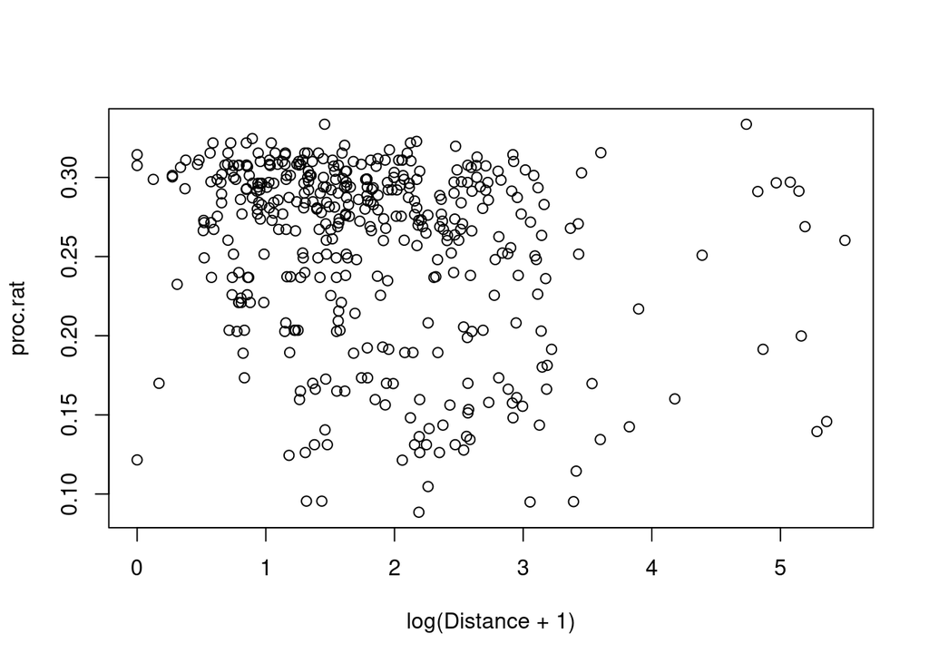

```r
plot(proc.rat~log(Distance+1),new.all.dist.m)
```

Using male body and tusk size ratio as a continous variable does not look well. We have significant results, but information loss as well.

### Investigating above-ground activities in males at the moment of capture

We standardized the activity comments/variable the data in excel.

```r
tabi<-read.csv(file="/media/hanna/HDD/Projektek/Lethrus/susa.cap.recap.2016/activ.male.cln.csv",sep=",")

head(tabi)
```

```
##    id megjegy sex     age  body proc       aktiv       date body.size
## 1  69      OK   m juvenil  9.55 1.00 patanyomban 2016-03-21     small
## 2  78      OK   m juvenil 10.27 0.96       járat 2016-03-22     small
## 3  81      OK   m juvenil 10.49 1.32   Achillea1 2016-03-22     small
## 4  88      OK   m juvenil 10.61 1.19       járat 2016-03-22     small
## 5 189      OK   m juvenil 10.34 1.19         ült 2016-03-25     small
## 6 204      OK   m juvenil 10.22 1.49       járat 2016-03-29     small
##     activity
## 1 vegetation
## 2     tunnel
## 3    feed_on
## 4     tunnel
## 5 vegetation
## 6     tunnel
```

```r
str(tabi)
```

```
## 'data.frame':    901 obs. of  10 variables:
##  $ id       : int  69 78 81 88 189 204 220 229 233 252 ...
##  $ megjegy  : chr  "OK" "OK" "OK" "OK" ...
##  $ sex      : chr  "m" "m" "m" "m" ...
##  $ age      : chr  "juvenil" "juvenil" "juvenil" "juvenil" ...
##  $ body     : num  9.55 10.27 10.49 10.61 10.34 ...
##  $ proc     : num  1 0.96 1.32 1.19 1.19 1.49 1.32 0.89 1.44 1.97 ...
##  $ aktiv    : chr  "patanyomban" "járat" "Achillea1" "járat" ...
##  $ date     : chr  "2016-03-21" "2016-03-22" "2016-03-22" "2016-03-22" ...
##  $ body.size: chr  "small" "small" "small" "small" ...
##  $ activity : chr  "vegetation" "tunnel" "feed_on" "tunnel" ...
```

```r
table(tabi$body.size)
```

```
##
## large   med small
##   450   392    59
```

As the body size categories were added a long time ago, before the body size breakpoints were determined, we will use the sex.cat variable instead of body.size.

```r
tabi$

tabi$id<-as.character(tabi$id)

table(tabi$body.size,tabi$activity)
```

```
##
##         dig feed_on fight mating tunnel vegetation
##   large  13      27    26      3    190        191
##   med    12      16    22      6    139        197
##   small   4       2     3      3     14         33
```

```r
nrow(tabi)
```

```
## [1] 901
```

```r
table(tabi$megjegy)
```

```
##
##       DEATH  NEWN    OK    XY
##    15    19     4   852    11
```

```r
tabi2<-tabi[tabi$megjegy!="NEWN",]

nrow(tabi2)
```

```
## [1] 897
```

```r
table(tabi2$body.size,tabi2$activity) #body size here is determined by sight and estimation not by test
```

```
##
##         dig feed_on fight mating tunnel vegetation
##   large  13      27    26      3    190        190
##   med    12      16    22      6    139        195
##   small   4       2     3      3     14         32
```

```r
table(tabi2$body.size)
```

```
##
## large   med small
##   449   390    58
```

```r
library(dplyr)
library(ggplot2)


tabi3<-table(tabi2$body.size,tabi2$activity)
```

Lets compare the individual IDs with the capture-recapture data. There should be a difference as we excluded individuals without coordinates during the analyses.

```r
i <- tabi2$id %in% new.all.capt.m$ID
ii <- new.all.capt.m$ID %in% tabi2$id
(missing.from.nalc <- as.character(tabi2$id[!i]))
```

```
##  [1] "1003" "1345" "1542" "394"  "509"  "533"  "779"  "794"  "824"  "872"
## [11] "909"  "988"  "995"  "1032" "1038" "1047" "1331" "1341" "1346" "1347"
## [21] "1348" "1528" "1529" "1533" "1536" "1538" "1539" "1540" "1547" "1553"
## [31] "503"  "523"  "631"  "875"  "993"  "996"  "1001" "1010" "1011" "1012"
## [41] "1013" "1016" "1022" "1023" "1024" "1029" "1030" "1031" "1034" "1035"
## [51] "1036" "1037" "1043" "1046" "1332" "1338" "1342" "1527" "1531" "1532"
## [61] "1535" "1537" "1546"
```

```r
(missing.from.tabi <- new.all.capt.m$ID[!ii])
```

```
## [1] NA
```

```r
head(new.all.capt.m)
```

```
##     ID sex B.width Tusk days     Age no.recaptures   tot.dist   max.dist
## 789  6   m   13.73 4.58   21 juvenil             2 116.132867 112.839463
## 790 14   m   13.63 4.11    7 juvenil             1   2.825914   2.825914
## 791 17   m   13.01 4.13    4 juvenil             1   6.105447   6.105447
## 792 36   m   13.06 4.06   16 juvenil             1   5.144336   5.144336
## 793 38   m   11.64 3.40   16 juvenil             1   6.532560   6.532560
## 794 49   m   11.93 3.72    1 juvenil             2   8.740943   5.494967
##     dist.a.day rel.bodywidth     sex.cat  proc.rat
## 789   5.530137     1.6710487  large.male 0.3335761
## 790   0.403702     1.5594399  large.male 0.3015407
## 791   1.526362     0.8674651  large.male 0.3174481
## 792   0.321521     0.9232695  large.male 0.3108729
## 793   0.408285    -0.6615761 middle.male 0.2920962
## 794   8.740943    -0.3379105 middle.male 0.3118189
```

```r
nrow(new.all.capt.m)
```

```
## [1] 835
```

```r
summary(tabi2$id)
```

```
##    Min. 1st Qu.  Median    Mean 3rd Qu.    Max.
##     6.0   357.0   756.0   803.2  1231.0  1789.0
```

```r
nrow(tabi2)
```

```
## [1] 897
```

```r
nrow(new.all.capt.m)
```

```
## [1] 835
```

```r
tabi222<-tabi2[,c(1,3,4,8,9,10)]
head(tabi222)
```

```
##    id sex     age       date body.size   activity
## 1  69   m juvenil 2016-03-21     small vegetation
## 2  78   m juvenil 2016-03-22     small     tunnel
## 3  81   m juvenil 2016-03-22     small    feed_on
## 4  88   m juvenil 2016-03-22     small     tunnel
## 5 189   m juvenil 2016-03-25     small vegetation
## 6 204   m juvenil 2016-03-29     small     tunnel
```

```r
names(tabi222)[1]<-"ID"

nalc<-new.all.capt.m[,c(1,2,12)]

behav.m<-merge(nalc,tabi222,by=c("ID","sex"),all.x=TRUE,all.y=FALSE)
behav.m
```

```
##       ID  sex     sex.cat          age       date body.size   activity
## 1      6    m  large.male      juvenil 2016-03-17     large vegetation
## 2      7    m  large.male      juvenil 2016-03-17     large vegetation
## 3      8    m  large.male      juvenil 2016-03-17     large vegetation
## 4      9    m middle.male      juvenil 2016-03-17     large    feed_on
## 5     13    m middle.male      juvenil 2016-03-17       med vegetation
## 6     14    m  large.male      juvenil 2016-03-17     large vegetation
## 7     15    m  large.male      juvenil 2016-03-17     large    feed_on
## 8     17    m  large.male      juvenil 2016-03-17     large vegetation
## 9     18    m  large.male      juvenil 2016-03-17     large vegetation
## 10    19    m middle.male      juvenil 2016-03-18       med vegetation
## 11    20    m middle.male      juvenil 2016-03-18     large     tunnel
## 12    21    m middle.male      juvenil 2016-03-18       med     tunnel
## 13    23    m middle.male      juvenil 2016-03-18       med vegetation
## 14    24    m  large.male      juvenil 2016-03-18     large    feed_on
```

[output cut: 821 more lines]

```r
nrow(behav.m)
```

```
## [1] 835
```

```r
nrow(nalc)
```

```
## [1] 835
```

```r
(bh.t<-table(behav.m$activity,behav.m$sex.cat)) # sex.cat shows the body size categories based on the 2 breakpoint segmented model
```

```
##
##              large.male middle.male small.male
##   dig                10           9          9
##   feed_on            22          18          3
##   fight              23          19          6
##   mating              2           3          5
##   tunnel            172         121         29
##   vegetation        166         158         59
```

```r
tabi.db <-as.data.frame(table(behav.m$sex.cat,behav.m$activity))

summary(tabi.db)
```

```
##           Var1           Var2        Freq
##  large.male :6   dig       :3   Min.   :  2.00
##  middle.male:6   feed_on   :3   1st Qu.:  6.75
##  small.male :6   fight     :3   Median : 18.50
##                  mating    :3   Mean   : 46.33
##                  tunnel    :3   3rd Qu.: 51.50
##                  vegetation:3   Max.   :172.00
```

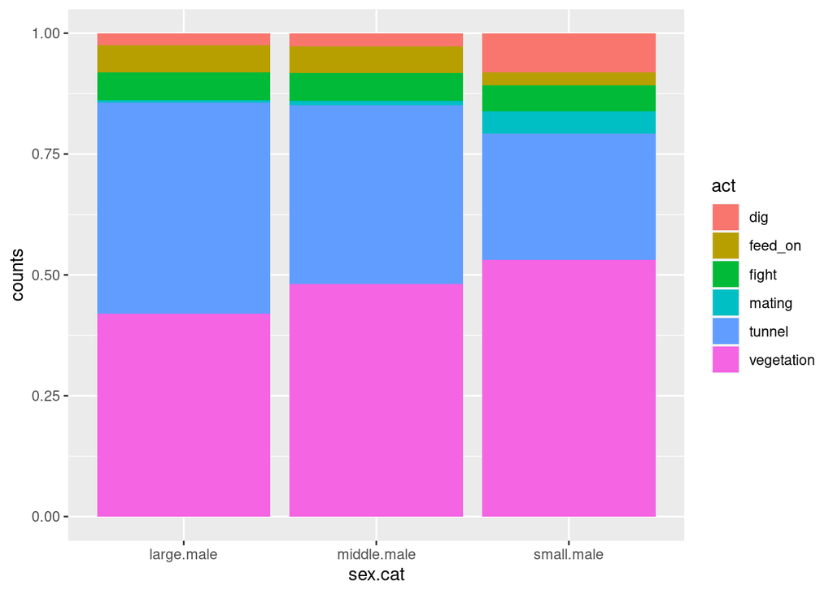

```r
names(tabi.db)[1] <-"sex.cat"
names(tabi.db)[2] <-"act"
names(tabi.db)[3] <-"counts"

ggplot(tabi.db, aes(fill=act, y=counts, x=sex.cat)) +
    geom_bar(position="fill", stat="identity")
```

```r
chisq<-chisq.test(bh.t)
chisq
```

```
##
##  Pearson's Chi-squared test
##
## data:  bh.t
## X-squared = 32.227, df = 10, p-value = 0.000367
```

```r
round(chisq$residuals,3)
```

```
##
##              large.male middle.male small.male
##   dig            -0.896      -0.606      2.732
##   feed_on         0.362       0.265     -1.138
##   fight           0.056       0.028     -0.154
##   mating         -1.257      -0.470      3.180
##   tunnel          1.579      -0.501     -2.117
##   vegetation     -1.143       0.601      1.124
```

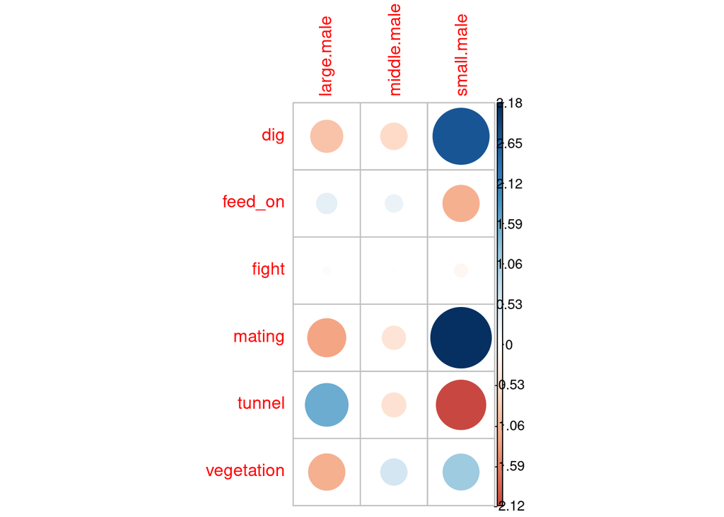

```r
library(corrplot)
corrplot(chisq$residuals,is.cor = FALSE)
```

```r
chisq2<-chisq.test(bh.t, simulate.p.value = TRUE)
round(chisq$expected,2)
```

```
##
##              large.male middle.male small.male
##   dig             13.26       11.01       3.73
##   feed_on         20.37       16.91       5.72
##   fight           22.73       18.88       6.39
##   mating           4.74        3.93       1.33
##   tunnel         152.51      126.64      42.86
##   vegetation     181.40      150.63      50.97
```

```r
chisq2
```

```
##
##  Pearson's Chi-squared test with simulated p-value (based on 2000
##  replicates)
##
## data:  bh.t
## X-squared = 32.227, df = NA, p-value = 0.0004998
```

```r
chisq
```

```
##
##  Pearson's Chi-squared test
##
## data:  bh.t
## X-squared = 32.227, df = 10, p-value = 0.000367
```

```r
round(chisq$expected,2)
```

```
##
##              large.male middle.male small.male
##   dig             13.26       11.01       3.73
##   feed_on         20.37       16.91       5.72
##   fight           22.73       18.88       6.39
##   mating           4.74        3.93       1.33
##   tunnel         152.51      126.64      42.86
##   vegetation     181.40      150.63      50.97
```

```r
bh.tn<-prop.table(bh.t,margin=1)
bh.tn
```

```
##
##              large.male middle.male small.male
##   dig        0.35714286  0.32142857 0.32142857
##   feed_on    0.51162791  0.41860465 0.06976744
##   fight      0.47916667  0.39583333 0.12500000
##   mating     0.20000000  0.30000000 0.50000000
##   tunnel     0.53416149  0.37577640 0.09006211
##   vegetation 0.43342037  0.41253264 0.15404700
```

```r
chisq.test(bh.tn)
```

```
##
##  Pearson's Chi-squared test
##
## data:  bh.tn
## X-squared = 0.88836, df = 10, p-value = 0.9999
```

#### Using multinomial models for investigating above-ground activities in male morphs

```r
library(nnet)

behav.m
```

```
##       ID  sex     sex.cat          age       date body.size   activity
## 1      6    m  large.male      juvenil 2016-03-17     large vegetation
## 2      7    m  large.male      juvenil 2016-03-17     large vegetation
## 3      8    m  large.male      juvenil 2016-03-17     large vegetation
## 4      9    m middle.male      juvenil 2016-03-17     large    feed_on
## 5     13    m middle.male      juvenil 2016-03-17       med vegetation
## 6     14    m  large.male      juvenil 2016-03-17     large vegetation
## 7     15    m  large.male      juvenil 2016-03-17     large    feed_on
## 8     17    m  large.male      juvenil 2016-03-17     large vegetation
## 9     18    m  large.male      juvenil 2016-03-17     large vegetation
## 10    19    m middle.male      juvenil 2016-03-18       med vegetation
## 11    20    m middle.male      juvenil 2016-03-18     large     tunnel
## 12    21    m middle.male      juvenil 2016-03-18       med     tunnel
## 13    23    m middle.male      juvenil 2016-03-18       med vegetation
## 14    24    m  large.male      juvenil 2016-03-18     large    feed_on
```

[output cut: 821 more lines]

```r
behav.m$date<-as.Date(behav.m$date)

behavm.mar<-behav.m %>% filter (behav.m$date<"2016-04-01")
behavm.mar$season<-"mar"

behavm.apr<- behav.m %>% filter (between(behav.m$date, as.Date("2016-04-01"), as.Date("2016-05-01")))
behavm.apr$season<-"apr"

behavm.maj<-behav.m %>% filter (behav.m$date>"2016-04-30")
behavm.maj$season<-"maj"

behav.mm<-rbind(behavm.mar,behavm.apr,behavm.maj)

behav.mm$date2
```

```r
behav.mc<-aggregate(sex.cat~factor(sex.cat)+season+activity,behav.mm,FUN=length)
str(behav.mc)
```

```
## 'data.frame':    44 obs. of  4 variables:
##  $ factor(sex.cat): Factor w/ 3 levels "large.male","middle.male",..: 1 2 3 1 2 3 1 2 3 2 ...
##  $ season         : chr  "apr" "apr" "apr" "mar" ...
##  $ activity       : chr  "dig" "dig" "dig" "dig" ...
##  $ sex.cat        : int  1 3 5 9 6 4 12 7 1 1 ...
```

```r
behav.mc$season<-as.factor(behav.mc$season)
behav.mc$activity<-as.factor(behav.mc$activity)

names(behav.mc)[names(behav.mc) == "factor(sex.cat)"] <- "male.cat"
names(behav.mc)[names(behav.mc) == "sex.cat"] <- "Freq"

colnames(behav.mc)
```

```
## [1] "male.cat" "season"   "activity" "Freq"
```

```r
with(behav.mc,table(male.cat,activity))
```

```
##              activity
## male.cat      dig feed_on fight mating tunnel vegetation
##   large.male    2       2     3      1      3          3
##   middle.male   2       3     3      1      3          3
##   small.male    2       3     2      2      3          3
```

UPDATE: For the further analyses, lets use the other database the behav.m one as we do not want to count with frequencies.

Lets choose small sized males as a baseline. Furthermore, the multinom package does not include p-value calculation for the regression coefficients, so we calculate p-values using Wald tests (here z-tests).

```r
summary(behav.mm)
```

```
##        ID             sex              sex.cat              age
##  Min.   :   6.0   Length:834         Length:834         Length:834
##  1st Qu.: 327.2   Class :character   Class :character   Class :character
##  Median : 717.0   Mode  :character   Mode  :character   Mode  :character
##  Mean   : 778.3
##  3rd Qu.:1206.8
##  Max.   :1789.0
##       date             body.size           activity            season
##  Min.   :2016-03-17   Length:834         Length:834         Length:834
##  1st Qu.:2016-03-31   Class :character   Class :character   Class :character
##  Median :2016-04-11   Mode  :character   Mode  :character   Mode  :character
##  Mean   :2016-04-12
##  3rd Qu.:2016-04-26
##  Max.   :2016-05-23
```

```r
behav.mm$sex.cat<-as.factor(behav.mm$sex.cat)
behav.mm$activity<-as.factor(behav.mm$activity)
behav.mm$season<-as.factor(behav.mm$season)
behav.mm$sex.cat2<-relevel(behav.mm$sex.cat, ref="small.male")
behav.mm$season2<-relevel(behav.mm$season, ref="mar")
behav.mm$activity2<-relevel(behav.mm$activity,ref="mating")
```

Now the models:

```r
library(nnet)
test.multi<-multinom(sex.cat2~season2+activity2,data=behav.mm)
summary(test.multi)
```

```
## Call:
## multinom(formula = sex.cat2 ~ season2 + activity2, data = behav.mm)
##
## Coefficients:
##             (Intercept) season2apr season2maj activity2dig activity2feed_on
## large.male  -0.11376575 -0.7210346 -0.9939538    0.4524294         2.521598
## middle.male -0.06155778 -0.3760451 -0.6195781    0.1973145         2.092837
##             activity2fight activity2tunnel activity2vegetation
## large.male        2.212851        2.479871            1.780082
## middle.male       1.646079        1.830235            1.421387
##
## Std. Errors:
##             (Intercept) season2apr season2maj activity2dig activity2feed_on
## large.male    0.8831305  0.2917908  0.3365501    0.9754215        1.0468110
## middle.male   0.7854483  0.2984331  0.3425102    0.8897871        0.9679078
##             activity2fight activity2tunnel activity2vegetation
## large.male       0.9556374       0.8634899           0.8534018
## middle.male      0.8688123       0.7622037           0.7491922
##
## Residual Deviance: 1611.437
## AIC: 1643.437
```

```r
test.multi2<-multinom(sex.cat2~(season2*activity2)^2,family=poisson,data=behav.mm)
summary(test.multi2)
```

```
## Call:
## multinom(formula = sex.cat2 ~ (season2 * activity2)^2, data = behav.mm,
##     family = poisson)
##
## Coefficients:
##             (Intercept) season2apr season2maj activity2dig activity2feed_on
## large.male    -3.916389  -20.80835   4.611193     4.727375         6.218238
## middle.male   -2.731954    2.44437 -14.979682     3.137508         5.033796
##             activity2fight activity2tunnel activity2vegetation
## large.male        16.06949        5.689442            5.897354
## middle.male       14.88498        4.061084            4.178840
##             season2apr:activity2dig season2maj:activity2dig
## large.male                 18.38762                       0
## middle.male                -3.36092                       0
##             season2apr:activity2feed_on season2maj:activity2feed_on
## large.male                    20.991578                   -37.95715
## middle.male                   -2.800119                    12.67795
##             season2apr:activity2fight season2maj:activity2fight
## large.male                   9.610771                 -14.68531
## middle.male                -13.721921                   4.43562
##             season2apr:activity2tunnel season2maj:activity2tunnel
## large.male                   20.751327                  -4.369432
## middle.male                  -2.341409                  15.259915
##             season2apr:activity2vegetation season2maj:activity2vegetation
## large.male                       19.835597                      -6.243868
## middle.male                      -2.817656                      14.161392
##
## Std. Errors:
##             (Intercept) season2apr season2maj activity2dig activity2feed_on
## large.male    0.5389497  0.3929716  0.7843064    0.7495027        1.0457027
## middle.male   0.4906968  0.4906968  0.4658142    0.7091417        0.9533308
##             activity2fight activity2tunnel activity2vegetation
## large.male       0.7836328       0.5979997           0.6031481
## middle.male      0.6660475       0.5701606           0.5773226
##             season2apr:activity2dig season2maj:activity2dig
## large.male                1.0792371            2.189058e-15
## middle.male               0.9690301            2.281611e-16
##             season2apr:activity2feed_on season2maj:activity2feed_on
## large.male                     1.233825                1.818252e-13
## middle.male                    1.355381                1.402190e+00
##             season2apr:activity2fight season2maj:activity2fight
## large.male                  0.6348277                 1.0775014
## middle.male                 0.7367033                 0.7983142
##             season2apr:activity2tunnel season2maj:activity2tunnel
## large.male                   0.5288187                  0.9487982
## middle.male                  0.6229102                  0.6790049
##             season2apr:activity2vegetation season2maj:activity2vegetation
## large.male                       0.5214793                      0.8622523
## middle.male                      0.6113349                      0.5776960
##
## Residual Deviance: 1585.682
## AIC: 1649.682
```

```r
anova(test.multi,test.multi2)
```

```
## Likelihood ratio tests of Multinomial Models
##
## Response: sex.cat2
##                     Model Resid. df Resid. Dev   Test    Df LR stat.    Pr(Chi)
## 1     season2 + activity2      1652   1611.437
## 2 (season2 * activity2)^2      1636   1585.682 1 vs 2    16 25.75537 0.05756904
```

```r
AIC(test.multi,test.multi2)
```

```
##             df      AIC
## test.multi  16 1643.437
## test.multi2 32 1649.682
```

It seems, test.multi, the additive model fits better, but the difference is not significant. Lets continue with the model containing interaction.

Lets do the 2 tailed z test

```r
z <- summary(test.multi2)$coefficients/summary(test.multi2)$standard.errors
z
```

```
##             (Intercept) season2apr season2maj activity2dig activity2feed_on
## large.male    -7.266706 -52.951276   5.879327     6.307350         5.946468
## middle.male   -5.567499   4.981426 -32.158059     4.424374         5.280220
##             activity2fight activity2tunnel activity2vegetation
## large.male        20.50640        9.514123            9.777623
## middle.male       22.34823        7.122702            7.238311
##             season2apr:activity2dig season2maj:activity2dig
## large.male                17.037613                       0
## middle.male               -3.468334                       0
##             season2apr:activity2feed_on season2maj:activity2feed_on
## large.male                    17.013410               -2.087563e+14
## middle.male                   -2.065927                9.041537e+00
##             season2apr:activity2fight season2maj:activity2fight
## large.male                   15.13918                -13.629043
## middle.male                 -18.62612                  5.556233
##             season2apr:activity2tunnel season2maj:activity2tunnel
## large.male                   39.240908                  -4.605228
## middle.male                  -3.758822                  22.473940
##             season2apr:activity2vegetation season2maj:activity2vegetation
## large.male                       38.037167                      -7.241347
## middle.male                      -4.609022                      24.513571
```

```r
p <- (1 - pnorm(abs(z), 0, 1)) * 2
p
```

```
##              (Intercept)   season2apr  season2maj activity2dig activity2feed_on
## large.male  3.683720e-13 0.000000e+00 4.11939e-09 2.838536e-10     2.739895e-09
## middle.male 2.584217e-08 6.311749e-07 0.00000e+00 9.672230e-06     1.290288e-07
##             activity2fight activity2tunnel activity2vegetation
## large.male               0    0.000000e+00        0.000000e+00
## middle.male              0    1.058265e-12        4.543033e-13
##             season2apr:activity2dig season2maj:activity2dig
## large.male             0.0000000000                       1
## middle.male            0.0005236969                       1
##             season2apr:activity2feed_on season2maj:activity2feed_on
## large.male                    0.0000000                           0
## middle.male                   0.0388354                           0
##             season2apr:activity2fight season2maj:activity2fight
## large.male                          0              0.000000e+00
## middle.male                         0              2.756588e-08
##             season2apr:activity2tunnel season2maj:activity2tunnel
## large.male                0.0000000000               4.120139e-06
## middle.male               0.0001707151               0.000000e+00
##             season2apr:activity2vegetation season2maj:activity2vegetation
## large.male                    0.000000e+00                   4.443113e-13
## middle.male                   4.045682e-06                   0.000000e+00
```

Just like binary logistic regression, we need to convert the coefficients to odds by taking the exponential of the coefficients.

```r
exp(coef(test.multi2))
```

```
##             (Intercept)   season2apr   season2maj activity2dig activity2feed_on
## large.male   0.01991286 9.184367e-10 1.006041e+02    112.99861         501.8183
## middle.male  0.06509198 1.152328e+01 3.121813e-07     23.04637         153.5147
##             activity2fight activity2tunnel activity2vegetation
## large.male         9525527        295.7287           364.07287
## middle.male        2913844         58.0372            65.29009
##             season2apr:activity2dig season2maj:activity2dig
## large.male             9.674836e+07                       1
## middle.male            3.470333e-02                       1
##             season2apr:activity2feed_on season2maj:activity2feed_on
## large.male                 1.307756e+09                3.276553e-17
## middle.male                6.080285e-02                3.206007e+05
##             season2apr:activity2fight season2maj:activity2fight
## large.male               1.492467e+04              4.190346e-07
## middle.male              1.098109e-06              8.440443e+01
##             season2apr:activity2tunnel season2maj:activity2tunnel
## large.male                1.028459e+09               1.265843e-02
## middle.male               9.619204e-02               4.239325e+06
##             season2apr:activity2vegetation season2maj:activity2vegetation
## large.male                    4.116141e+08                   1.942328e-03
## middle.male                   5.974582e-02                   1.413235e+06
```

```r
head(round(fitted(test.multi2), 2))
```

```
##   small.male large.male middle.male
## 1       0.08       0.58        0.34
## 2       0.08       0.58        0.34
## 3       0.08       0.58        0.34
## 4       0.05       0.48        0.48
## 5       0.08       0.58        0.34
## 6       0.08       0.58        0.34
```

Analyses above give us not too much information, as the baseline used by the model is equal to observed frequency of mating in small males in March. One possible solution to do the tests separated for each month. Another idea to transform the Date into a numeric variable (Julian date). Lets do the last option.

```r
behav.mm$j.date<-as.numeric(format(behav.mm$date, format = "%j"))-76 # number of days since the start of the experiment

test.multij<-multinom(sex.cat2~j.date+activity2,dat=behav.mm)
summary(test.multij)
```

```
## Call:
## multinom(formula = sex.cat2 ~ j.date + activity2, data = behav.mm)
##
## Coefficients:
##             (Intercept)      j.date activity2dig activity2feed_on
## large.male   -0.2607334 -0.01939224    0.6394291         2.624641
## middle.male  -0.1488471 -0.01052887    0.2987847         2.150800
##             activity2fight activity2tunnel activity2vegetation
## large.male        2.296286        2.566594            1.893584
## middle.male       1.685824        1.872715            1.472808
##
## Std. Errors:
##             (Intercept)      j.date activity2dig activity2feed_on
## large.male    0.8718930 0.007004969    0.9669756         1.046034
## middle.male   0.7706067 0.007048418    0.8818570         0.966581
##             activity2fight activity2tunnel activity2vegetation
## large.male       0.9577159       0.8642660           0.8535347
## middle.male      0.8691617       0.7614206           0.7475576
##
## Residual Deviance: 1614.528
## AIC: 1642.528
```

```r
test.multij2<-multinom(sex.cat2~(j.date+activity2)^2,data=behav.mm)
summary(test.multij2)
```

```
## Call:
## multinom(formula = sex.cat2 ~ (j.date + activity2)^2, data = behav.mm)
##
## Coefficients:
##             (Intercept)     j.date activity2dig activity2feed_on activity2fight
## large.male   -11.576462  0.2429083   13.0259053     14.161176808      11.944489
## middle.male    2.485801 -0.1064883   -0.3090108     -0.009664673      -1.356328
##             activity2tunnel activity2vegetation j.date:activity2dig
## large.male        13.021540          13.7950007         -0.33198333
## middle.male       -1.500156          -0.8438082         -0.04712586
##             j.date:activity2feed_on j.date:activity2fight
## large.male              -0.27121036            -0.2150679
## middle.male              0.07303471             0.1072011
##             j.date:activity2tunnel j.date:activity2vegetation
## large.male              -0.2293612                -0.28048315
## middle.male              0.1241036                 0.08728626
##
## Std. Errors:
##             (Intercept)     j.date activity2dig activity2feed_on activity2fight
## large.male    0.3827632 0.02914352     1.219450         1.040562       1.083427
## middle.male   4.1022778 0.14878062     4.361941         4.273318       4.278886
##             activity2tunnel activity2vegetation j.date:activity2dig
## large.male        0.5088704           0.4776223          0.08882738
## middle.male       4.1241613           4.1176201          0.17859174
##             j.date:activity2feed_on j.date:activity2fight
## large.male               0.04986202            0.04186008
## middle.male              0.15543957            0.15273581
##             j.date:activity2tunnel j.date:activity2vegetation
## large.male              0.03222237                 0.03023534
## middle.male             0.14957438                 0.14905345
##
## Residual Deviance: 1589.907
## AIC: 1637.907
```

```r
anova(test.multij,test.multij2)
```

```
## Likelihood ratio tests of Multinomial Models
##
## Response: sex.cat2
##                    Model Resid. df Resid. Dev   Test    Df LR stat.     Pr(Chi)
## 1     j.date + activity2      1654   1614.528
## 2 (j.date + activity2)^2      1644   1589.907 1 vs 2    10  24.6209 0.006112321
```

```r
AIC(test.multij,test.multij2)
```

```
##              df      AIC
## test.multij  14 1642.528
## test.multij2 24 1637.907
```

```r
z2 <- summary(test.multij2)$coefficients/summary(test.multij2)$standard.errors
z2
```

```
##             (Intercept)     j.date activity2dig activity2feed_on activity2fight
## large.male  -30.2444469  8.3349006  10.68178743     13.609159601     11.0247295
## middle.male   0.6059563 -0.7157404  -0.07084251     -0.002261632     -0.3169815
##             activity2tunnel activity2vegetation j.date:activity2dig
## large.male       25.5891097          28.8826558          -3.7373984
## middle.male      -0.3637482          -0.2049262          -0.2638748
##             j.date:activity2feed_on j.date:activity2fight
## large.male               -5.4392169            -5.1377801
## middle.male               0.4698592             0.7018726
##             j.date:activity2tunnel j.date:activity2vegetation
## large.male              -7.1180741                 -9.2766673
## middle.male              0.8297116                  0.5856037
```

```r
p2 <- (1 - pnorm(abs(z2), 0, 1)) * 2
p2
```

```
##             (Intercept)    j.date activity2dig activity2feed_on activity2fight
## large.male    0.0000000 0.0000000    0.0000000        0.0000000      0.0000000
## middle.male   0.5445437 0.4741517    0.9435231        0.9981955      0.7512576
##             activity2tunnel activity2vegetation j.date:activity2dig
## large.male        0.0000000           0.0000000        0.0001859342
## middle.male       0.7160461           0.8376298        0.7918763855
##             j.date:activity2feed_on j.date:activity2fight
## large.male             5.351527e-08          2.780029e-07
## middle.male            6.384556e-01          4.827586e-01
##             j.date:activity2tunnel j.date:activity2vegetation
## large.male            1.094458e-12                  0.0000000
## middle.male           4.067019e-01                  0.5581418
```

```r
studyl<-c(1:68)
summary(studyl)
```

```
##    Min. 1st Qu.  Median    Mean 3rd Qu.    Max.
##    1.00   17.75   34.50   34.50   51.25   68.00
```

We conducted the experiment for 68 days. According to that the first qu. is 18, the second qu. is 35 and the third qu. is 51. In the previous version quartiles were given in the emmeans using “at=list(j.date=(1:3*0.25))“, but this setting put the quartiles to day16,day26,day41 because of the missing survey days. Taking the 18th, 35th and 51th days we get information about the 25%, 50%, and 75% days ellapsed since the start of the season/experiment.

```r
phmulti<-emmeans(test.multij2, ~sex.cat2 |j.date * activity2, at=list(j.date=c(18,35,51)))
test(phmulti)
```

```
## j.date = 18, activity2 = mating:
##  sex.cat2        prob       SE df t.ratio p.value
##  small.male  0.361368 0.358191 24   1.009  0.3231
##  large.male  0.000269 0.000318 24   0.844  0.4071
##  middle.male 0.638364 0.358472 24   1.781  0.0876
##
## j.date = 35, activity2 = mating:
##  sex.cat2        prob       SE df t.ratio p.value
##  small.male  0.748942 0.232293 24   3.224  0.0036
##  large.male  0.034605 0.033198 24   1.042  0.3076
##  middle.male 0.216453 0.236810 24   0.914  0.3698
##
## j.date = 51, activity2 = mating:
##  sex.cat2        prob       SE df t.ratio p.value
##  small.male  0.302600 0.298378 24   1.014  0.3206
##  large.male  0.681484 0.307423 24   2.217  0.0364
##  middle.male 0.015916 0.056784 24   0.280  0.7817
##
## j.date = 18, activity2 = dig:
##  sex.cat2        prob       SE df t.ratio p.value
##  small.male  0.414483 0.117442 24   3.529  0.0017
##  large.male  0.355358 0.113440 24   3.133  0.0045
##  middle.male 0.230158 0.103965 24   2.214  0.0366
##
## j.date = 35, activity2 = dig:
##  sex.cat2        prob       SE df t.ratio p.value
##  small.male  0.813429 0.260585 24   3.122  0.0046
##  large.male  0.153404 0.232241 24   0.661  0.5152
##  middle.male 0.033167 0.064211 24   0.517  0.6102
##
## j.date = 51, activity2 = dig:
##  sex.cat2        prob       SE df t.ratio p.value
##  small.male  0.953435 0.139013 24   6.859  <.0001
##  large.male  0.043237 0.132854 24   0.325  0.7477
##  middle.male 0.003329 0.011978 24   0.278  0.7835
##
## j.date = 18, activity2 = feed_on:
##  sex.cat2        prob       SE df t.ratio p.value
##  small.male  0.064596 0.038772 24   1.666  0.1087
##  large.male  0.514619 0.076648 24   6.714  <.0001
```

[output cut: 52 more lines]

```
##  small.male  0.107172 0.019848 24   5.400  <.0001
##  large.male  0.501011 0.031288 24  16.013  <.0001
##  middle.male 0.391816 0.030540 24  12.829  <.0001
##
## j.date = 35, activity2 = vegetation:
##  sex.cat2        prob       SE df t.ratio p.value
##  small.male  0.163780 0.019745 24   8.295  <.0001
##  large.male  0.404213 0.027013 24  14.964  <.0001
##  middle.male 0.432008 0.026870 24  16.078  <.0001
##
## j.date = 51, activity2 = vegetation:
##  sex.cat2        prob       SE df t.ratio p.value
##  small.male  0.232945 0.034575 24   6.737  <.0001
##  large.male  0.315142 0.037379 24   8.431  <.0001
##  middle.male 0.451913 0.040108 24  11.267  <.0001
```

```r
tab.ph<-contrast(phmulti, method="pairwise",adjust="tukey")
pairs(phmulti)
```

```
## j.date = 18, activity2 = mating:
##  contrast                 estimate     SE df t.ratio p.value
##  small.male - large.male    0.3611 0.3579 24   1.009  0.5785
##  small.male - middle.male  -0.2770 0.7167 24  -0.387  0.9212
##  large.male - middle.male  -0.6381 0.3588 24  -1.779  0.1980
##
## j.date = 35, activity2 = mating:
##  contrast                 estimate     SE df t.ratio p.value
##  small.male - large.male    0.7143 0.2325 24   3.073  0.0139
##  small.male - middle.male   0.5325 0.4679 24   1.138  0.5008
##  large.male - middle.male  -0.1818 0.2458 24  -0.740  0.7425
##
## j.date = 51, activity2 = mating:
##  contrast                 estimate     SE df t.ratio p.value
##  small.male - large.male   -0.3789 0.6032 24  -0.628  0.8062
##  small.male - middle.male   0.2867 0.3000 24   0.956  0.6113
##  large.male - middle.male   0.6656 0.3262 24   2.040  0.1243
##
## j.date = 18, activity2 = dig:
##  contrast                 estimate     SE df t.ratio p.value
##  small.male - large.male    0.0591 0.2062 24   0.287  0.9558
##  small.male - middle.male   0.1843 0.1906 24   0.967  0.6042
##  large.male - middle.male   0.1252 0.1832 24   0.683  0.7753
##
## j.date = 35, activity2 = dig:
##  contrast                 estimate     SE df t.ratio p.value
##  small.male - large.male    0.6600 0.4894 24   1.349  0.3831
##  small.male - middle.male   0.7803 0.3002 24   2.599  0.0402
##  large.male - middle.male   0.1202 0.2196 24   0.548  0.8487
##
## j.date = 51, activity2 = dig:
##  contrast                 estimate     SE df t.ratio p.value
##  small.male - large.male    0.9102 0.2717 24   3.350  0.0072
##  small.male - middle.male   0.9501 0.1459 24   6.512  <.0001
##  large.male - middle.male   0.0399 0.1275 24   0.313  0.9476
##
## j.date = 18, activity2 = feed_on:
##  contrast                 estimate     SE df t.ratio p.value
##  small.male - large.male   -0.4500 0.0950 24  -4.735  0.0002
##  small.male - middle.male  -0.3562 0.0926 24  -3.845  0.0022
```

[output cut: 54 more lines]

```
##  large.male - middle.male   0.1092 0.0586 24   1.865  0.1708
##
## j.date = 35, activity2 = vegetation:
##  contrast                 estimate     SE df t.ratio p.value
##  small.male - large.male   -0.2404 0.0390 24  -6.173  <.0001
##  small.male - middle.male  -0.2682 0.0387 24  -6.940  <.0001
##  large.male - middle.male  -0.0278 0.0501 24  -0.554  0.8452
##
## j.date = 51, activity2 = vegetation:
##  contrast                 estimate     SE df t.ratio p.value
##  small.male - large.male   -0.0822 0.0598 24  -1.374  0.3697
##  small.male - middle.male  -0.2190 0.0649 24  -3.374  0.0068
##  large.male - middle.male  -0.1368 0.0694 24  -1.971  0.1412
##
## P value adjustment: tukey method for comparing a family of 3 estimates
```

```r
summary(tab.ph)
```

```
## j.date = 18, activity2 = mating:
##  contrast                 estimate     SE df t.ratio p.value
##  small.male - large.male    0.3611 0.3579 24   1.009  0.5785
##  small.male - middle.male  -0.2770 0.7167 24  -0.387  0.9212
##  large.male - middle.male  -0.6381 0.3588 24  -1.779  0.1980
##
## j.date = 35, activity2 = mating:
##  contrast                 estimate     SE df t.ratio p.value
##  small.male - large.male    0.7143 0.2325 24   3.073  0.0139
##  small.male - middle.male   0.5325 0.4679 24   1.138  0.5008
##  large.male - middle.male  -0.1818 0.2458 24  -0.740  0.7425
##
## j.date = 51, activity2 = mating:
##  contrast                 estimate     SE df t.ratio p.value
##  small.male - large.male   -0.3789 0.6032 24  -0.628  0.8062
##  small.male - middle.male   0.2867 0.3000 24   0.956  0.6113
##  large.male - middle.male   0.6656 0.3262 24   2.040  0.1243
##
## j.date = 18, activity2 = dig:
##  contrast                 estimate     SE df t.ratio p.value
##  small.male - large.male    0.0591 0.2062 24   0.287  0.9558
##  small.male - middle.male   0.1843 0.1906 24   0.967  0.6042
##  large.male - middle.male   0.1252 0.1832 24   0.683  0.7753
##
## j.date = 35, activity2 = dig:
##  contrast                 estimate     SE df t.ratio p.value
##  small.male - large.male    0.6600 0.4894 24   1.349  0.3831
##  small.male - middle.male   0.7803 0.3002 24   2.599  0.0402
##  large.male - middle.male   0.1202 0.2196 24   0.548  0.8487
##
## j.date = 51, activity2 = dig:
##  contrast                 estimate     SE df t.ratio p.value
##  small.male - large.male    0.9102 0.2717 24   3.350  0.0072
##  small.male - middle.male   0.9501 0.1459 24   6.512  <.0001
##  large.male - middle.male   0.0399 0.1275 24   0.313  0.9476
##
## j.date = 18, activity2 = feed_on:
##  contrast                 estimate     SE df t.ratio p.value
##  small.male - large.male   -0.4500 0.0950 24  -4.735  0.0002
##  small.male - middle.male  -0.3562 0.0926 24  -3.845  0.0022
```

[output cut: 54 more lines]

```
##  large.male - middle.male   0.1092 0.0586 24   1.865  0.1708
##
## j.date = 35, activity2 = vegetation:
##  contrast                 estimate     SE df t.ratio p.value
##  small.male - large.male   -0.2404 0.0390 24  -6.173  <.0001
##  small.male - middle.male  -0.2682 0.0387 24  -6.940  <.0001
##  large.male - middle.male  -0.0278 0.0501 24  -0.554  0.8452
##
## j.date = 51, activity2 = vegetation:
##  contrast                 estimate     SE df t.ratio p.value
##  small.male - large.male   -0.0822 0.0598 24  -1.374  0.3697
##  small.male - middle.male  -0.2190 0.0649 24  -3.374  0.0068
##  large.male - middle.male  -0.1368 0.0694 24  -1.971  0.1412
##
## P value adjustment: tukey method for comparing a family of 3 estimates
```

```r
comparison_table <- as.data.frame(summary(tab.ph))
write.csv(tab.ph, "emmeans_quantile_comparisons.csv", row.names = FALSE)
```

Lets make a plot showing activity frequences per male morph:

```r
library(grid)
library(gridExtra)


sm<-behav.mm[behav.mm$sex.cat=="small.male",]

nrow(sm)
```

```
## [1] 111
```

```r
sm.db<-data.frame(with(sm, table(j.date, activity)))

sm.db$perc<-(sm.db$Freq/111)*100


smed<-behav.mm[behav.mm$sex.cat=="middle.male",]

smed.db<-data.frame(with(smed, table(j.date, activity)))

smed.db$perc<-(smed.db$Freq/328)*100


smed.dat<-smed.db[,1,drop=FALSE]
smed.datt<-distinct(smed.dat)
smed.datt
```

```
##    j.date
## 1       1
## 2       2
## 3       5
## 4       6
## 5       7
## 6       8
## 7       9
## 8      13
## 9      14
## 10     15
## 11     16
## 12     17
## 13     18
## 14     21
```

[output cut: 24 more lines]

```r
sm.m<-data.frame(j.date=c("1","2","7","8","17","22","30","38","41","43","51","62","68"),
                          activity="dig",Freq=0,perc=0)

sm.dbb<-rbind(sm.db,sm.m)
as.data.frame(sm.dbb)
```

```
##     j.date   activity Freq      perc
## 1        5        dig    0 0.0000000
## 2        6        dig    0 0.0000000
## 3        7        dig    0 0.0000000
## 4        9        dig    0 0.0000000
## 5       13        dig    1 0.9009009
## 6       14        dig    2 1.8018018
## 7       15        dig    1 0.9009009
## 8       16        dig    3 2.7027027
## 9       17        dig    0 0.0000000
## 10      18        dig    1 0.9009009
## 11      21        dig    0 0.0000000
## 12      22        dig    0 0.0000000
## 13      26        dig    1 0.9009009
## 14      27        dig    0 0.0000000
```

[output cut: 197 more lines]

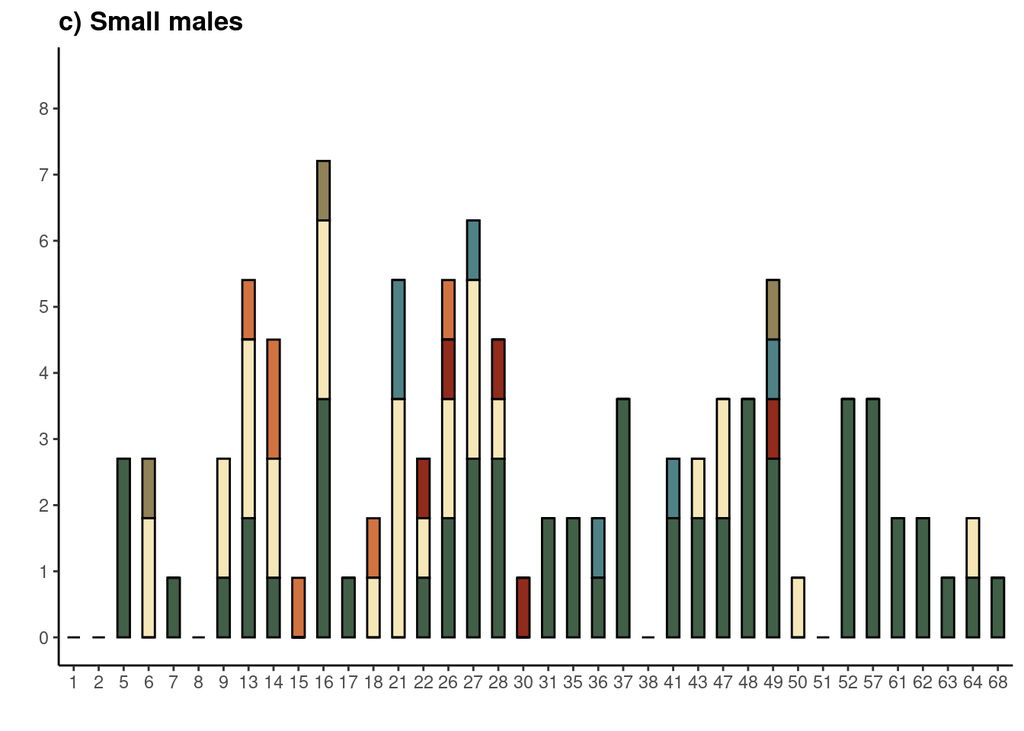

```r
sorted_labels <- paste(sort(as.integer(levels(sm.dbb$j.date))))

sm.dbb$j.date <- factor(sm.dbb$j.date, levels = sorted_labels)

sm.dbbb<-with(sm.dbb,sm.dbb[order(sm.dbb$j.date),])




cols2<- c(dig="#d17341",feed_on="#918257",fight="#4f8286",mating="#912b1b",
          tunnel="#f6e7b9", vegetation="#425f47")

require(ggplot2)

smp1<-ggplot(sm.dbbb, aes(x=j.date, y=perc, group = activity, color=activity,fill=activity))+
  geom_col(colour="black",width= 0.5) +
  labs(title="c) Small males",x=" ",y=" ")+
  theme_classic()+theme(plot.title = element_text(size=13, face="bold"),legend.position="none") + scale_y_continuous(limits=c(0,8.5),breaks=seq(0,8.5,1))+ scale_fill_manual(values=cols2,labels=c('Feeding',"Fighting","Attempting to mate", "Being the entrance of a tunnel","Being in vegetation"))

smp1
```

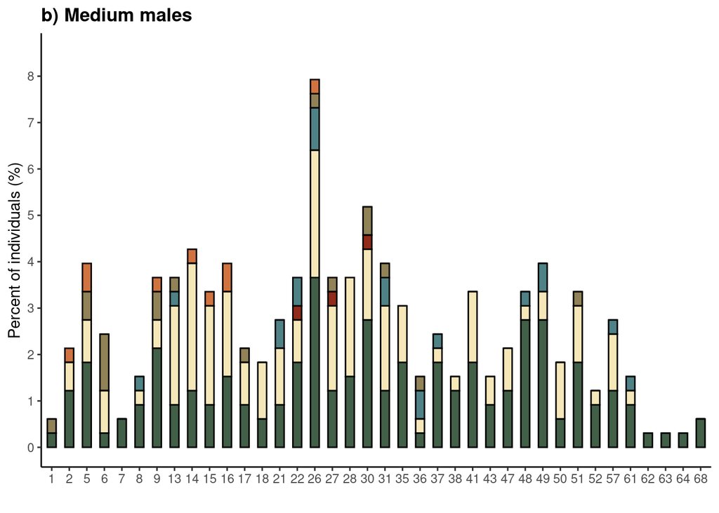

```r
smp11<-smp1+ labs(x="Number of days since start of the experiment", y="")+ theme(text=element_text(size=20))+theme (axis.text.x = element_text(face = "bold", size=12),  axis.text.y = element_text(face = "bold", size = 12),panel.border = element_rect(colour = "black", fill=NA, size=0.2))


smedp1<-ggplot(smed.db, aes(x=j.date, y=perc, group = activity,color=activity,fill=activity))+
  geom_col(colour="black",width= 0.5)+
  labs(title="b) Medium males",x=" ", y = "Percent of individuals (%)")+ theme_classic()+theme(plot.title = element_text(size=13, face="bold"),legend.position="none")+ scale_y_continuous(limits=c(0,8.5),breaks=seq(0,8.5,1)) + scale_fill_manual(values=cols2,labels=c('Feeding',"Fighting","Attempting to mate", "Being the entrance of a tunnel","Being in vegetation"))

smedp1
```

```r
smedp11<-smedp1 + labs(y="Percent of individuals (%)", x="") + theme(text=element_text(size=20))+theme (axis.text.x = element_text(face = "bold", size=12),  axis.text.y = element_text(face = "bold", size = 12),panel.border = element_rect(colour = "black", fill=NA, size=0.2))
smedp11

sl<-behav.mm[behav.mm$sex.cat=="large.male",]

sl.db<-data.frame(with(sl, table(j.date, activity)))

sl.db$perc<-(sl.db$Freq/395)*100



sl.m<-data.frame(j.date=c("38"),
                 activity="dig",Freq=0,perc=0)

sl.dbb<-rbind(sl.db,sl.m)
as.data.frame(sl.dbb)
```

```
##     j.date   activity Freq      perc
## 1        1        dig    0 0.0000000
## 2        2        dig    0 0.0000000
## 3        5        dig    1 0.2531646
## 4        6        dig    0 0.0000000
## 5        7        dig    0 0.0000000
## 6        8        dig    0 0.0000000
## 7        9        dig    1 0.2531646
## 8       13        dig    2 0.5063291
## 9       14        dig    3 0.7594937
## 10      15        dig    2 0.5063291
## 11      16        dig    0 0.0000000
## 12      17        dig    0 0.0000000
## 13      18        dig    0 0.0000000
## 14      21        dig    0 0.0000000
```

[output cut: 209 more lines]

```r
sorted_labels <- paste(sort(as.integer(levels(sl.dbb$j.date))))

sl.dbb$j.date <- factor(sl.dbb$j.date, levels = sorted_labels)

sl.dbbb<-with(sl.dbb,sl.dbb[order(sl.dbb$j.date),])



slp1<-ggplot(sl.dbbb, aes(x=j.date, y=perc, group = activity, color=activity,fill=activity))+
  geom_col(colour="black",width= 0.5)+
  labs(title="a) Large males",x="",y="")+
  theme_classic()+
  theme(plot.title = element_text(size=13, face="bold"))+
  scale_y_continuous(limits=c(0,8.5),breaks=seq(0,8.5,1))+ scale_fill_manual(values=cols2,labels=c("Digging", "Feeding","Fighting","Attempting to mate", "Being at the entrance","Being in vegetation"))

slp11<-slp1+labs(x="", y="") + guides(fill=guide_legend(title="Observed behaviour"))+ theme(text=element_text(size=20))+theme (axis.text.x = element_text(face = "bold", size=12),  axis.text.y = element_text(face = "bold", size = 12),panel.border = element_rect(colour = "black", fill=NA, size=0.2))

legend<-get_legend(slp11)
slp11 <- slp11 + theme(legend.position="none")


blank <- grid.rect(gp=gpar(col="white"))
```

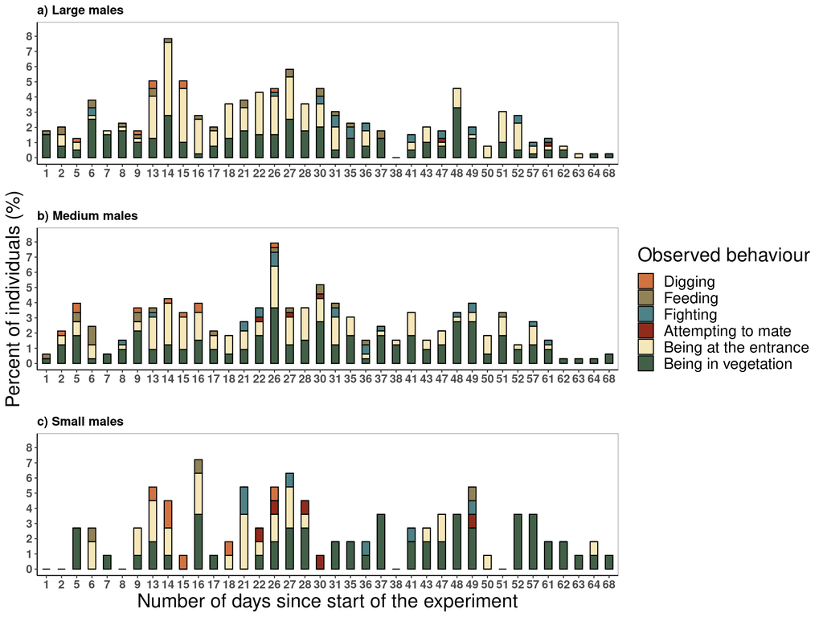

```r
fig3a<-grid.arrange(slp11,blank,smedp11,legend,smp11,blank,nrow=3,ncol=2, widths=c(2.5, 0.8),heights = c(3, 3,3))
```

```r
ggsave("seasonal.movement.Figure.3a.tiff", fig3a, units="px",height= 4500, width= 4000,dpi=300)
```